# Wrange and Analyze WeRateDogs

## by Emily Aquin

This project expects the student to gather data from Twitter, specifically the Twitter user @dog_rates, or WeRateDogs. The goal of this Twitter account is to use humor to rate pictures of dogs, usually giving ratings higher than 10/10. The data was scraped, and then quality and tidiness issues were cleaned. This data can then be visualized in Jupyter Notebooks.

```python
import pandas as pd
import numpy as np
import requests
import tweepy
import json
import time
import datetime
import os
import seaborn as sns
import matplotlib.pyplot as plt
% matplotlib inline
import re

#Display entire sales
pd.set_option('display.max_colwidth', -1)
```

## Gather Data

```python
#load CSV file into DataFrame, from WeRateDogs Twitter
twitter_archive = pd.read_csv('twitter-archive-enhanced.csv')
```

Download dog prediction images programmatically using the Requests Library

```python
#Make directory if it doesn't already exist
folder_name = 'dog_images'
if not os.path.exists(folder_name):
    os.makedirs(folder_name)
```

```python
dog_image_url = 'https://d17h27t6h515a5.cloudfront.net/topher/2017/August/599fd2ad_image-predictions/image-predictions.tsv'
response = requests.get(dog_image_url)
```

```python
with open(os.path.join(folder_name, dog_image_url.split('/')[-1]), mode='wb') as file:
    file.write(response.content)
```

```python
prediction = pd.read_csv('dog_images/image-predictions.tsv', sep='\t')
```

```python
prediction.head()
```

|  | tweet_id | jpg_url | img_num | p1 | p1_conf | p1_dog | p2 | p2_conf | p2_dog | p3 | p3_conf | p3_dog |
| --- | --- | --- | --- | --- | --- | --- | --- | --- | --- | --- | --- | --- |
| 0 | 666020888022790149 | https://pbs.twimg.com/media/CT4udn0WwAA0aMy.jpg | 1 | Welsh_springer_spaniel | 0.465074 | True | collie | 0.156665 | True | Shetland_sheepdog | 0.061428 | True |
| 1 | 666029285002620928 | https://pbs.twimg.com/media/CT42GRgUYAA5iDo.jpg | 1 | redbone | 0.506826 | True | miniature_pinscher | 0.074192 | True | Rhodesian_ridgeback | 0.072010 | True |
| 2 | 666033412701032449 | https://pbs.twimg.com/media/CT4521TWwAEvMyu.jpg | 1 | German_shepherd | 0.596461 | True | malinois | 0.138584 | True | bloodhound | 0.116197 | True |
| 3 | 666044226329800704 | https://pbs.twimg.com/media/CT5Dr8HUEAA-lEu.jpg | 1 | Rhodesian_ridgeback | 0.408143 | True | redbone | 0.360687 | True | miniature_pinscher | 0.222752 | True |
| 4 | 666049248165822465 | https://pbs.twimg.com/media/CT5IQmsXIAAKY4A.jpg | 1 | miniature_pinscher | 0.560311 | True | Rottweiler | 0.243682 | True | Doberman | 0.154629 | True |

Use Tweepy library to query the Twitter API for each tweet's JSON data

```python
consumer_key = 'HIDDEN'
consumer_secret = 'HIDDEN'
access_token = 'HIDDEN'
access_secret = 'HIDDEN'

auth = tweepy.OAuthHandler(consumer_key, consumer_secret)
auth.set_access_token(access_token, access_secret)
api = tweepy.API(auth, wait_on_rate_limit = True, wait_on_rate_limit_notify = True)
```

```python
tweet = api.get_status(twitter_archive.tweet_id[1543], tweet_mode='extended')
#json info
j_info = tweet._json
j_info
```

[output not shown]

[output cut: 45 more lines]

```
  'follow_request_sent': False,
  'notifications': False,
  'translator_type': 'none'},
 'geo': None,
 'coordinates': None,
 'place': None,
 'contributors': None,
 'is_quote_status': False,
 'retweet_count': 481,
 'favorite_count': 2118,
 'favorited': False,
 'retweeted': False,
 'possibly_sensitive': False,
 'possibly_sensitive_appealable': False,
 'lang': 'en'}
```

```python
j_info['favorite_count']
```

```
2118
```

```python
j_info['user']['followers_count']
```

```
8131641
```

```python
tweet_ids = list(twitter_archive['tweet_id'])
```

```python
t = time.process_time()

with open('tweet_json.txt', 'w') as file:
    for tweet_id in tweet_ids:
        try:
            tweet = api.get_status(tweet_id, tweet_mode = 'extended')
            json.dump(tweet._json, file)
            file.write('\n')
            print(tweet_id)
        except Exception as e:
            print(e)

elapsed_time = time.process_time() - t
print(elapsed_time)
```

```python
df_list = []

with open('tweet_json.txt', 'r', encoding='utf8') as f:
    for line in f:
        tweet_line = json.loads(line)
        df_list.append({'favorites': tweet_line['favorite_count'],
                       'retweets': tweet_line['retweet_count'],
                       'followers_count': tweet_line['user']['followers_count'],
                       'tweet_id': tweet_line['id']})

twitter_api = pd.DataFrame(df_list)
print(twitter_api)
```

```
      favorites  followers_count  retweets            tweet_id
0     37466      8130304          8158      892420643555336193
1     32194      8130304          6037      892177421306343426
2     24271      8130304          3996      891815181378084864
3     40779      8130304          8311      891689557279858688
4     38999      8130304          9007      891327558926688256
5     19602      8130304          2988      891087950875897856
6     11445      8130962          1984      890971913173991426
7     63181      8130304          18123     890729181411237888
8     26961      8130304          4102      890609185150312448
9     30894      8130304          7091      890240255349198849
10    29709      8130304          7046      890006608113172480
11    26957      8130304          4787      889880896479866881
12    46559      8130304          9643      889665388333682689
13    26238      8130304          4357      889638837579907072
```

[output cut: 49 more lines]

## Visual Assessment

### JSON file

```python
twitter_api
```

|  | favorites | followers_count | retweets | tweet_id |
| --- | --- | --- | --- | --- |
| 0 | 37466 | 8130304 | 8158 | 892420643555336193 |
| 1 | 32194 | 8130304 | 6037 | 892177421306343426 |
| 2 | 24271 | 8130304 | 3996 | 891815181378084864 |
| 3 | 40779 | 8130304 | 8311 | 891689557279858688 |
| 4 | 38999 | 8130304 | 9007 | 891327558926688256 |
| 5 | 19602 | 8130304 | 2988 | 891087950875897856 |
| 6 | 11445 | 8130962 | 1984 | 890971913173991426 |
| 7 | 63181 | 8130304 | 18123 | 890729181411237888 |
| 8 | 26961 | 8130304 | 4102 | 890609185150312448 |
| 9 | 30894 | 8130304 | 7091 | 890240255349198849 |
| 10 | 29709 | 8130304 | 7046 | 890006608113172480 |
| 11 | 26957 | 8130304 | 4787 | 889880896479866881 |
| 12 | 46559 | 8130304 | 9643 | 889665388333682689 |
| 13 | 26238 | 8130304 | 4357 | 889638837579907072 |
| 14 | 14636 | 8130304 | 2165 | 889531135344209921 |
| 15 | 24447 | 8130304 | 5169 | 889278841981685760 |
| 16 | 28201 | 8130304 | 4335 | 888917238123831296 |
| 17 | 24752 | 8130304 | 4116 | 888804989199671297 |
| 18 | 19198 | 8130304 | 3394 | 888554962724278272 |
| 19 | 21064 | 8130304 | 3346 | 888078434458587136 |
| 20 | 29240 | 8130304 | 5173 | 887705289381826560 |
| 21 | 44854 | 8130304 | 11251 | 887517139158093824 |
| 22 | 66717 | 8130304 | 17446 | 887473957103951883 |
| 23 | 32603 | 8130304 | 10029 | 887343217045368832 |
| 24 | 29609 | 8130304 | 5727 | 887101392804085760 |
| 25 | 33987 | 8130304 | 7448 | 886983233522544640 |
| 26 | 11646 | 8130304 | 3134 | 886736880519319552 |
| 27 | 21726 | 8130304 | 4287 | 886680336477933568 |
| 28 | 20499 | 8130962 | 3076 | 886366144734445568 |
| 29 | 116 | 8130304 | 4 | 886267009285017600 |
| ... | ... | ... | ... | ... |
| 2305 | 428 | 8130404 | 320 | 666411507551481857 |
| 2306 | 103 | 8130404 | 37 | 666407126856765440 |
| 2307 | 161 | 8130404 | 81 | 666396247373291520 |
| 2308 | 180 | 8130404 | 88 | 666373753744588802 |
| 2309 | 752 | 8130404 | 555 | 666362758909284353 |
| 2310 | 211 | 8130404 | 71 | 666353288456101888 |
| 2311 | 283 | 8130404 | 131 | 666345417576210432 |
| 2312 | 191 | 8130404 | 88 | 666337882303524864 |
| 2313 | 485 | 8130404 | 342 | 666293911632134144 |
| 2314 | 141 | 8130404 | 63 | 666287406224695296 |
| 2315 | 167 | 8130404 | 75 | 666273097616637952 |
| 2316 | 99 | 8130404 | 34 | 666268910803644416 |
| 2317 | 13900 | 8130404 | 6302 | 666104133288665088 |
| 2318 | 76 | 8130404 | 11 | 666102155909144576 |
| 2319 | 149 | 8130404 | 64 | 666099513787052032 |
| 2320 | 158 | 8130404 | 70 | 666094000022159362 |
| 2321 | 111 | 8130404 | 43 | 666082916733198337 |
| 2322 | 312 | 8130404 | 157 | 666073100786774016 |
| 2323 | 139 | 8130404 | 57 | 666071193221509120 |
| 2324 | 458 | 8130404 | 211 | 666063827256086533 |
| 2325 | 108 | 8130404 | 57 | 666058600524156928 |
| 2326 | 284 | 8130404 | 136 | 666057090499244032 |
| 2327 | 421 | 8130404 | 232 | 666055525042405380 |
| 2328 | 1184 | 8130404 | 825 | 666051853826850816 |
| 2329 | 129 | 8130404 | 56 | 666050758794694657 |
| 2330 | 104 | 8130404 | 41 | 666049248165822465 |
| 2331 | 288 | 8130404 | 135 | 666044226329800704 |
| 2332 | 120 | 8130404 | 43 | 666033412701032449 |
| 2333 | 124 | 8130404 | 46 | 666029285002620928 |
| 2334 | 2499 | 8130404 | 493 | 666020888022790149 |

2335 rows × 4 columns

- favorites: number of likes
- followers_count: number of followers
- retweets: number of times this Tweet has been retweeted
- tweet_id: unique number to identify each Tweet

### Image Prediction File

```python
prediction
```

|  | tweet_id | jpg_url | img_num | p1 | p1_conf | p1_dog | p2 | p2_conf | p2_dog | p3 | p3_conf | p3_dog |
| --- | --- | --- | --- | --- | --- | --- | --- | --- | --- | --- | --- | --- |
| 0 | 666020888022790149 | https://pbs.twimg.com/media/CT4udn0WwAA0aMy.jpg | 1 | Welsh_springer_spaniel | 0.465074 | True | collie | 0.156665 | True | Shetland_sheepdog | 0.061428 | True |
| 1 | 666029285002620928 | https://pbs.twimg.com/media/CT42GRgUYAA5iDo.jpg | 1 | redbone | 0.506826 | True | miniature_pinscher | 0.074192 | True | Rhodesian_ridgeback | 0.072010 | True |
| 2 | 666033412701032449 | https://pbs.twimg.com/media/CT4521TWwAEvMyu.jpg | 1 | German_shepherd | 0.596461 | True | malinois | 0.138584 | True | bloodhound | 0.116197 | True |
| 3 | 666044226329800704 | https://pbs.twimg.com/media/CT5Dr8HUEAA-lEu.jpg | 1 | Rhodesian_ridgeback | 0.408143 | True | redbone | 0.360687 | True | miniature_pinscher | 0.222752 | True |
| 4 | 666049248165822465 | https://pbs.twimg.com/media/CT5IQmsXIAAKY4A.jpg | 1 | miniature_pinscher | 0.560311 | True | Rottweiler | 0.243682 | True | Doberman | 0.154629 | True |
| 5 | 666050758794694657 | https://pbs.twimg.com/media/CT5Jof1WUAEuVxN.jpg | 1 | Bernese_mountain_dog | 0.651137 | True | English_springer | 0.263788 | True | Greater_Swiss_Mountain_dog | 0.016199 | True |
| 6 | 666051853826850816 | https://pbs.twimg.com/media/CT5KoJ1WoAAJash.jpg | 1 | box_turtle | 0.933012 | False | mud_turtle | 0.045885 | False | terrapin | 0.017885 | False |
| 7 | 666055525042405380 | https://pbs.twimg.com/media/CT5N9tpXIAAifs1.jpg | 1 | chow | 0.692517 | True | Tibetan_mastiff | 0.058279 | True | fur_coat | 0.054449 | False |
| 8 | 666057090499244032 | https://pbs.twimg.com/media/CT5PY90WoAAQGLo.jpg | 1 | shopping_cart | 0.962465 | False | shopping_basket | 0.014594 | False | golden_retriever | 0.007959 | True |
| 9 | 666058600524156928 | https://pbs.twimg.com/media/CT5Qw94XAAA_2dP.jpg | 1 | miniature_poodle | 0.201493 | True | komondor | 0.192305 | True | soft-coated_wheaten_terrier | 0.082086 | True |
| 10 | 666063827256086533 | https://pbs.twimg.com/media/CT5Vg_wXIAAXfnj.jpg | 1 | golden_retriever | 0.775930 | True | Tibetan_mastiff | 0.093718 | True | Labrador_retriever | 0.072427 | True |
| 11 | 666071193221509120 | https://pbs.twimg.com/media/CT5cN_3WEAAlOoZ.jpg | 1 | Gordon_setter | 0.503672 | True | Yorkshire_terrier | 0.174201 | True | Pekinese | 0.109454 | True |
| 12 | 666073100786774016 | https://pbs.twimg.com/media/CT5d9DZXAAALcwe.jpg | 1 | Walker_hound | 0.260857 | True | English_foxhound | 0.175382 | True | Ibizan_hound | 0.097471 | True |
| 13 | 666082916733198337 | https://pbs.twimg.com/media/CT5m4VGWEAAtKc8.jpg | 1 | pug | 0.489814 | True | bull_mastiff | 0.404722 | True | French_bulldog | 0.048960 | True |
| 14 | 666094000022159362 | https://pbs.twimg.com/media/CT5w9gUW4AAsBNN.jpg | 1 | bloodhound | 0.195217 | True | German_shepherd | 0.078260 | True | malinois | 0.075628 | True |
| 15 | 666099513787052032 | https://pbs.twimg.com/media/CT51-JJUEAA6hV8.jpg | 1 | Lhasa | 0.582330 | True | Shih-Tzu | 0.166192 | True | Dandie_Dinmont | 0.089688 | True |
| 16 | 666102155909144576 | https://pbs.twimg.com/media/CT54YGiWUAEZnoK.jpg | 1 | English_setter | 0.298617 | True | Newfoundland | 0.149842 | True | borzoi | 0.133649 | True |
| 17 | 666104133288665088 | https://pbs.twimg.com/media/CT56LSZWoAAlJj2.jpg | 1 | hen | 0.965932 | False | cock | 0.033919 | False | partridge | 0.000052 | False |
| 18 | 666268910803644416 | https://pbs.twimg.com/media/CT8QCd1WEAADXws.jpg | 1 | desktop_computer | 0.086502 | False | desk | 0.085547 | False | bookcase | 0.079480 | False |
| 19 | 666273097616637952 | https://pbs.twimg.com/media/CT8T1mtUwAA3aqm.jpg | 1 | Italian_greyhound | 0.176053 | True | toy_terrier | 0.111884 | True | basenji | 0.111152 | True |
| 20 | 666287406224695296 | https://pbs.twimg.com/media/CT8g3BpUEAAuFjg.jpg | 1 | Maltese_dog | 0.857531 | True | toy_poodle | 0.063064 | True | miniature_poodle | 0.025581 | True |
| 21 | 666293911632134144 | https://pbs.twimg.com/media/CT8mx7KW4AEQu8N.jpg | 1 | three-toed_sloth | 0.914671 | False | otter | 0.015250 | False | great_grey_owl | 0.013207 | False |
| 22 | 666337882303524864 | https://pbs.twimg.com/media/CT9OwFIWEAMuRje.jpg | 1 | ox | 0.416669 | False | Newfoundland | 0.278407 | True | groenendael | 0.102643 | True |
| 23 | 666345417576210432 | https://pbs.twimg.com/media/CT9Vn7PWoAA_ZCM.jpg | 1 | golden_retriever | 0.858744 | True | Chesapeake_Bay_retriever | 0.054787 | True | Labrador_retriever | 0.014241 | True |
| 24 | 666353288456101888 | https://pbs.twimg.com/media/CT9cx0tUEAAhNN_.jpg | 1 | malamute | 0.336874 | True | Siberian_husky | 0.147655 | True | Eskimo_dog | 0.093412 | True |
| 25 | 666362758909284353 | https://pbs.twimg.com/media/CT9lXGsUcAAyUFt.jpg | 1 | guinea_pig | 0.996496 | False | skunk | 0.002402 | False | hamster | 0.000461 | False |
| 26 | 666373753744588802 | https://pbs.twimg.com/media/CT9vZEYWUAAlZ05.jpg | 1 | soft-coated_wheaten_terrier | 0.326467 | True | Afghan_hound | 0.259551 | True | briard | 0.206803 | True |
| 27 | 666396247373291520 | https://pbs.twimg.com/media/CT-D2ZHWIAA3gK1.jpg | 1 | Chihuahua | 0.978108 | True | toy_terrier | 0.009397 | True | papillon | 0.004577 | True |
| 28 | 666407126856765440 | https://pbs.twimg.com/media/CT-NvwmW4AAugGZ.jpg | 1 | black-and-tan_coonhound | 0.529139 | True | bloodhound | 0.244220 | True | flat-coated_retriever | 0.173810 | True |
| 29 | 666411507551481857 | https://pbs.twimg.com/media/CT-RugiWIAELEaq.jpg | 1 | coho | 0.404640 | False | barracouta | 0.271485 | False | gar | 0.189945 | False |
| ... | ... | ... | ... | ... | ... | ... | ... | ... | ... | ... | ... | ... |
| 2045 | 886366144734445568 | https://pbs.twimg.com/media/DE0BTnQUwAApKEH.jpg | 1 | French_bulldog | 0.999201 | True | Chihuahua | 0.000361 | True | Boston_bull | 0.000076 | True |
| 2046 | 886680336477933568 | https://pbs.twimg.com/media/DE4fEDzWAAAyHMM.jpg | 1 | convertible | 0.738995 | False | sports_car | 0.139952 | False | car_wheel | 0.044173 | False |
| 2047 | 886736880519319552 | https://pbs.twimg.com/media/DE5Se8FXcAAJFx4.jpg | 1 | kuvasz | 0.309706 | True | Great_Pyrenees | 0.186136 | True | Dandie_Dinmont | 0.086346 | True |
| 2048 | 886983233522544640 | https://pbs.twimg.com/media/DE8yicJW0AAAvBJ.jpg | 2 | Chihuahua | 0.793469 | True | toy_terrier | 0.143528 | True | can_opener | 0.032253 | False |
| 2049 | 887101392804085760 | https://pbs.twimg.com/media/DE-eAq6UwAA-jaE.jpg | 1 | Samoyed | 0.733942 | True | Eskimo_dog | 0.035029 | True | Staffordshire_bullterrier | 0.029705 | True |
| 2050 | 887343217045368832 | https://pbs.twimg.com/ext_tw_video_thumb/887343120832229379/pu/img/6HSuFrW1lzI_9Mht.jpg | 1 | Mexican_hairless | 0.330741 | True | sea_lion | 0.275645 | False | Weimaraner | 0.134203 | True |
| 2051 | 887473957103951883 | https://pbs.twimg.com/media/DFDw2tyUQAAAFke.jpg | 2 | Pembroke | 0.809197 | True | Rhodesian_ridgeback | 0.054950 | True | beagle | 0.038915 | True |
| 2052 | 887517139158093824 | https://pbs.twimg.com/ext_tw_video_thumb/887517108413886465/pu/img/WanJKwssZj4VJvL9.jpg | 1 | limousine | 0.130432 | False | tow_truck | 0.029175 | False | shopping_cart | 0.026321 | False |
| 2053 | 887705289381826560 | https://pbs.twimg.com/media/DFHDQBbXgAEqY7t.jpg | 1 | basset | 0.821664 | True | redbone | 0.087582 | True | Weimaraner | 0.026236 | True |
| 2054 | 888078434458587136 | https://pbs.twimg.com/media/DFMWn56WsAAkA7B.jpg | 1 | French_bulldog | 0.995026 | True | pug | 0.000932 | True | bull_mastiff | 0.000903 | True |
| 2055 | 888202515573088257 | https://pbs.twimg.com/media/DFDw2tyUQAAAFke.jpg | 2 | Pembroke | 0.809197 | True | Rhodesian_ridgeback | 0.054950 | True | beagle | 0.038915 | True |
| 2056 | 888554962724278272 | https://pbs.twimg.com/media/DFTH_O-UQAACu20.jpg | 3 | Siberian_husky | 0.700377 | True | Eskimo_dog | 0.166511 | True | malamute | 0.111411 | True |
| 2057 | 888804989199671297 | https://pbs.twimg.com/media/DFWra-3VYAA2piG.jpg | 1 | golden_retriever | 0.469760 | True | Labrador_retriever | 0.184172 | True | English_setter | 0.073482 | True |
| 2058 | 888917238123831296 | https://pbs.twimg.com/media/DFYRgsOUQAARGhO.jpg | 1 | golden_retriever | 0.714719 | True | Tibetan_mastiff | 0.120184 | True | Labrador_retriever | 0.105506 | True |
| 2059 | 889278841981685760 | https://pbs.twimg.com/ext_tw_video_thumb/889278779352338437/pu/img/VlbFB3v8H8VwzVNY.jpg | 1 | whippet | 0.626152 | True | borzoi | 0.194742 | True | Saluki | 0.027351 | True |
| 2060 | 889531135344209921 | https://pbs.twimg.com/media/DFg_2PVW0AEHN3p.jpg | 1 | golden_retriever | 0.953442 | True | Labrador_retriever | 0.013834 | True | redbone | 0.007958 | True |
| 2061 | 889638837579907072 | https://pbs.twimg.com/media/DFihzFfXsAYGDPR.jpg | 1 | French_bulldog | 0.991650 | True | boxer | 0.002129 | True | Staffordshire_bullterrier | 0.001498 | True |
| 2062 | 889665388333682689 | https://pbs.twimg.com/media/DFi579UWsAAatzw.jpg | 1 | Pembroke | 0.966327 | True | Cardigan | 0.027356 | True | basenji | 0.004633 | True |
| 2063 | 889880896479866881 | https://pbs.twimg.com/media/DFl99B1WsAITKsg.jpg | 1 | French_bulldog | 0.377417 | True | Labrador_retriever | 0.151317 | True | muzzle | 0.082981 | False |
| 2064 | 890006608113172480 | https://pbs.twimg.com/media/DFnwSY4WAAAMliS.jpg | 1 | Samoyed | 0.957979 | True | Pomeranian | 0.013884 | True | chow | 0.008167 | True |
| 2065 | 890240255349198849 | https://pbs.twimg.com/media/DFrEyVuW0AAO3t9.jpg | 1 | Pembroke | 0.511319 | True | Cardigan | 0.451038 | True | Chihuahua | 0.029248 | True |
| 2066 | 890609185150312448 | https://pbs.twimg.com/media/DFwUU__XcAEpyXI.jpg | 1 | Irish_terrier | 0.487574 | True | Irish_setter | 0.193054 | True | Chesapeake_Bay_retriever | 0.118184 | True |
| 2067 | 890729181411237888 | https://pbs.twimg.com/media/DFyBahAVwAAhUTd.jpg | 2 | Pomeranian | 0.566142 | True | Eskimo_dog | 0.178406 | True | Pembroke | 0.076507 | True |
| 2068 | 890971913173991426 | https://pbs.twimg.com/media/DF1eOmZXUAALUcq.jpg | 1 | Appenzeller | 0.341703 | True | Border_collie | 0.199287 | True | ice_lolly | 0.193548 | False |
| 2069 | 891087950875897856 | https://pbs.twimg.com/media/DF3HwyEWsAABqE6.jpg | 1 | Chesapeake_Bay_retriever | 0.425595 | True | Irish_terrier | 0.116317 | True | Indian_elephant | 0.076902 | False |
| 2070 | 891327558926688256 | https://pbs.twimg.com/media/DF6hr6BUMAAzZgT.jpg | 2 | basset | 0.555712 | True | English_springer | 0.225770 | True | German_short-haired_pointer | 0.175219 | True |
| 2071 | 891689557279858688 | https://pbs.twimg.com/media/DF_q7IAWsAEuuN8.jpg | 1 | paper_towel | 0.170278 | False | Labrador_retriever | 0.168086 | True | spatula | 0.040836 | False |
| 2072 | 891815181378084864 | https://pbs.twimg.com/media/DGBdLU1WsAANxJ9.jpg | 1 | Chihuahua | 0.716012 | True | malamute | 0.078253 | True | kelpie | 0.031379 | True |
| 2073 | 892177421306343426 | https://pbs.twimg.com/media/DGGmoV4XsAAUL6n.jpg | 1 | Chihuahua | 0.323581 | True | Pekinese | 0.090647 | True | papillon | 0.068957 | True |
| 2074 | 892420643555336193 | https://pbs.twimg.com/media/DGKD1-bXoAAIAUK.jpg | 1 | orange | 0.097049 | False | bagel | 0.085851 | False | banana | 0.076110 | False |

2075 rows × 12 columns

This file has 2075 rows and 12 columns, which are:

- tweet_id: the final part of the URL, after status
- jpg_URL: where the image is hosted
- img_num: the image number that matches the most confident prediction, from 1 to 4
- p1: the algorithm's first choice to predict the image in the tweet
- p1_conf: how confident the algorithm is that the image is a breed of dog, in percentage
- p1_dog: true or false, if the predicition is indeed a breed of dog
- p2: algorithm's second most likely prediction
- p2_conf: how confident the algorithm is that the image is a breed of dog, in percentage
- p2_dog: true or false, if the predicition is indeed a breed of dog

### The Twitter Archive File

```python
twitter_archive
```

|  | tweet_id | in_reply_to_status_id | in_reply_to_user_id | timestamp | source | text | retweeted_status_id | retweeted_status_user_id | retweeted_status_timestamp | expanded_urls | rating_numerator | rating_denominator | name | doggo | floofer | pupper | puppo |
| --- | --- | --- | --- | --- | --- | --- | --- | --- | --- | --- | --- | --- | --- | --- | --- | --- | --- |
| 0 | 892420643555336193 | NaN | NaN | 2017-08-01 16:23:56 +0000 | <a href="http://twitter.com/download/iphone" rel="nofollow">Twitter for iPhone</a> | This is Phineas. He's a mystical boy. Only ever appears in the hole of a donut. 13/10 https://t.co/MgUWQ76dJU | NaN | NaN | NaN | https://twitter.com/dog_rates/status/892420643555336193/photo/1 | 13 | 10 | Phineas | None | None | None | None |
| 1 | 892177421306343426 | NaN | NaN | 2017-08-01 00:17:27 +0000 | <a href="http://twitter.com/download/iphone" rel="nofollow">Twitter for iPhone</a> | This is Tilly. She's just checking pup on you. Hopes you're doing ok. If not, she's available for pats, snugs, boops, the whole bit. 13/10 https://t.co/0Xxu71qeIV | NaN | NaN | NaN | https://twitter.com/dog_rates/status/892177421306343426/photo/1 | 13 | 10 | Tilly | None | None | None | None |
| 2 | 891815181378084864 | NaN | NaN | 2017-07-31 00:18:03 +0000 | <a href="http://twitter.com/download/iphone" rel="nofollow">Twitter for iPhone</a> | This is Archie. He is a rare Norwegian Pouncing Corgo. Lives in the tall grass. You never know when one may strike. 12/10 https://t.co/wUnZnhtVJB | NaN | NaN | NaN | https://twitter.com/dog_rates/status/891815181378084864/photo/1 | 12 | 10 | Archie | None | None | None | None |
| 3 | 891689557279858688 | NaN | NaN | 2017-07-30 15:58:51 +0000 | <a href="http://twitter.com/download/iphone" rel="nofollow">Twitter for iPhone</a> | This is Darla. She commenced a snooze mid meal. 13/10 happens to the best of us https://t.co/tD36da7qLQ | NaN | NaN | NaN | https://twitter.com/dog_rates/status/891689557279858688/photo/1 | 13 | 10 | Darla | None | None | None | None |
| 4 | 891327558926688256 | NaN | NaN | 2017-07-29 16:00:24 +0000 | <a href="http://twitter.com/download/iphone" rel="nofollow">Twitter for iPhone</a> | This is Franklin. He would like you to stop calling him "cute." He is a very fierce shark and should be respected as such. 12/10 #BarkWeek https://t.co/AtUZn91f7f | NaN | NaN | NaN | https://twitter.com/dog_rates/status/891327558926688256/photo/1,https://twitter.com/dog_rates/status/891327558926688256/photo/1 | 12 | 10 | Franklin | None | None | None | None |
| 5 | 891087950875897856 | NaN | NaN | 2017-07-29 00:08:17 +0000 | <a href="http://twitter.com/download/iphone" rel="nofollow">Twitter for iPhone</a> | Here we have a majestic great white breaching off South Africa's coast. Absolutely h*ckin breathtaking. 13/10 (IG: tucker_marlo) #BarkWeek https://t.co/kQ04fDDRmh | NaN | NaN | NaN | https://twitter.com/dog_rates/status/891087950875897856/photo/1 | 13 | 10 | None | None | None | None | None |
| 6 | 890971913173991426 | NaN | NaN | 2017-07-28 16:27:12 +0000 | <a href="http://twitter.com/download/iphone" rel="nofollow">Twitter for iPhone</a> | Meet Jax. He enjoys ice cream so much he gets nervous around it. 13/10 help Jax enjoy more things by clicking below\n\nhttps://t.co/Zr4hWfAs1H https://t.co/tVJBRMnhxl | NaN | NaN | NaN | https://gofundme.com/ydvmve-surgery-for-jax,https://twitter.com/dog_rates/status/890971913173991426/photo/1 | 13 | 10 | Jax | None | None | None | None |
| 7 | 890729181411237888 | NaN | NaN | 2017-07-28 00:22:40 +0000 | <a href="http://twitter.com/download/iphone" rel="nofollow">Twitter for iPhone</a> | When you watch your owner call another dog a good boy but then they turn back to you and say you're a great boy. 13/10 https://t.co/v0nONBcwxq | NaN | NaN | NaN | https://twitter.com/dog_rates/status/890729181411237888/photo/1,https://twitter.com/dog_rates/status/890729181411237888/photo/1 | 13 | 10 | None | None | None | None | None |
| 8 | 890609185150312448 | NaN | NaN | 2017-07-27 16:25:51 +0000 | <a href="http://twitter.com/download/iphone" rel="nofollow">Twitter for iPhone</a> | This is Zoey. She doesn't want to be one of the scary sharks. Just wants to be a snuggly pettable boatpet. 13/10 #BarkWeek https://t.co/9TwLuAGH0b | NaN | NaN | NaN | https://twitter.com/dog_rates/status/890609185150312448/photo/1 | 13 | 10 | Zoey | None | None | None | None |
| 9 | 890240255349198849 | NaN | NaN | 2017-07-26 15:59:51 +0000 | <a href="http://twitter.com/download/iphone" rel="nofollow">Twitter for iPhone</a> | This is Cassie. She is a college pup. Studying international doggo communication and stick theory. 14/10 so elegant much sophisticate https://t.co/t1bfwz5S2A | NaN | NaN | NaN | https://twitter.com/dog_rates/status/890240255349198849/photo/1 | 14 | 10 | Cassie | doggo | None | None | None |
| 10 | 890006608113172480 | NaN | NaN | 2017-07-26 00:31:25 +0000 | <a href="http://twitter.com/download/iphone" rel="nofollow">Twitter for iPhone</a> | This is Koda. He is a South Australian deckshark. Deceptively deadly. Frighteningly majestic. 13/10 would risk a petting #BarkWeek https://t.co/dVPW0B0Mme | NaN | NaN | NaN | https://twitter.com/dog_rates/status/890006608113172480/photo/1,https://twitter.com/dog_rates/status/890006608113172480/photo/1 | 13 | 10 | Koda | None | None | None | None |
| 11 | 889880896479866881 | NaN | NaN | 2017-07-25 16:11:53 +0000 | <a href="http://twitter.com/download/iphone" rel="nofollow">Twitter for iPhone</a> | This is Bruno. He is a service shark. Only gets out of the water to assist you. 13/10 terrifyingly good boy https://t.co/u1XPQMl29g | NaN | NaN | NaN | https://twitter.com/dog_rates/status/889880896479866881/photo/1 | 13 | 10 | Bruno | None | None | None | None |
| 12 | 889665388333682689 | NaN | NaN | 2017-07-25 01:55:32 +0000 | <a href="http://twitter.com/download/iphone" rel="nofollow">Twitter for iPhone</a> | Here's a puppo that seems to be on the fence about something haha no but seriously someone help her. 13/10 https://t.co/BxvuXk0UCm | NaN | NaN | NaN | https://twitter.com/dog_rates/status/889665388333682689/photo/1 | 13 | 10 | None | None | None | None | puppo |
| 13 | 889638837579907072 | NaN | NaN | 2017-07-25 00:10:02 +0000 | <a href="http://twitter.com/download/iphone" rel="nofollow">Twitter for iPhone</a> | This is Ted. He does his best. Sometimes that's not enough. But it's ok. 12/10 would assist https://t.co/f8dEDcrKSR | NaN | NaN | NaN | https://twitter.com/dog_rates/status/889638837579907072/photo/1,https://twitter.com/dog_rates/status/889638837579907072/photo/1 | 12 | 10 | Ted | None | None | None | None |
| 14 | 889531135344209921 | NaN | NaN | 2017-07-24 17:02:04 +0000 | <a href="http://twitter.com/download/iphone" rel="nofollow">Twitter for iPhone</a> | This is Stuart. He's sporting his favorite fanny pack. Secretly filled with bones only. 13/10 puppared puppo #BarkWeek https://t.co/y70o6h3isq | NaN | NaN | NaN | https://twitter.com/dog_rates/status/889531135344209921/photo/1 | 13 | 10 | Stuart | None | None | None | puppo |
| 15 | 889278841981685760 | NaN | NaN | 2017-07-24 00:19:32 +0000 | <a href="http://twitter.com/download/iphone" rel="nofollow">Twitter for iPhone</a> | This is Oliver. You're witnessing one of his many brutal attacks. Seems to be playing with his victim. 13/10 fr*ckin frightening #BarkWeek https://t.co/WpHvrQedPb | NaN | NaN | NaN | https://twitter.com/dog_rates/status/889278841981685760/video/1 | 13 | 10 | Oliver | None | None | None | None |
| 16 | 888917238123831296 | NaN | NaN | 2017-07-23 00:22:39 +0000 | <a href="http://twitter.com/download/iphone" rel="nofollow">Twitter for iPhone</a> | This is Jim. He found a fren. Taught him how to sit like the good boys. 12/10 for both https://t.co/chxruIOUJN | NaN | NaN | NaN | https://twitter.com/dog_rates/status/888917238123831296/photo/1 | 12 | 10 | Jim | None | None | None | None |
| 17 | 888804989199671297 | NaN | NaN | 2017-07-22 16:56:37 +0000 | <a href="http://twitter.com/download/iphone" rel="nofollow">Twitter for iPhone</a> | This is Zeke. He has a new stick. Very proud of it. Would like you to throw it for him without taking it. 13/10 would do my best https://t.co/HTQ77yNQ5K | NaN | NaN | NaN | https://twitter.com/dog_rates/status/888804989199671297/photo/1,https://twitter.com/dog_rates/status/888804989199671297/photo/1 | 13 | 10 | Zeke | None | None | None | None |
| 18 | 888554962724278272 | NaN | NaN | 2017-07-22 00:23:06 +0000 | <a href="http://twitter.com/download/iphone" rel="nofollow">Twitter for iPhone</a> | This is Ralphus. He's powering up. Attempting maximum borkdrive. 13/10 inspirational af https://t.co/YnYAFCTTiK | NaN | NaN | NaN | https://twitter.com/dog_rates/status/888554962724278272/photo/1,https://twitter.com/dog_rates/status/888554962724278272/photo/1,https://twitter.com/dog_rates/status/888554962724278272/photo/1,https://… | 13 | 10 | Ralphus | None | None | None | None |
| 19 | 888202515573088257 | NaN | NaN | 2017-07-21 01:02:36 +0000 | <a href="http://twitter.com/download/iphone" rel="nofollow">Twitter for iPhone</a> | RT @dog_rates: This is Canela. She attempted some fancy porch pics. They were unsuccessful. 13/10 someone help her https://t.co/cLyzpcUcMX | 8.874740e+17 | 4.196984e+09 | 2017-07-19 00:47:34 +0000 | https://twitter.com/dog_rates/status/887473957103951883/photo/1,https://twitter.com/dog_rates/status/887473957103951883/photo/1,https://twitter.com/dog_rates/status/887473957103951883/photo/1,https://… | 13 | 10 | Canela | None | None | None | None |
| 20 | 888078434458587136 | NaN | NaN | 2017-07-20 16:49:33 +0000 | <a href="http://twitter.com/download/iphone" rel="nofollow">Twitter for iPhone</a> | This is Gerald. He was just told he didn't get the job he interviewed for. A h*ckin injustice. 12/10 didn't want the job anyway https://t.co/DK7iDPfuRX | NaN | NaN | NaN | https://twitter.com/dog_rates/status/888078434458587136/photo/1,https://twitter.com/dog_rates/status/888078434458587136/photo/1 | 12 | 10 | Gerald | None | None | None | None |
| 21 | 887705289381826560 | NaN | NaN | 2017-07-19 16:06:48 +0000 | <a href="http://twitter.com/download/iphone" rel="nofollow">Twitter for iPhone</a> | This is Jeffrey. He has a monopoly on the pool noodles. Currently running a 'boop for two' midweek sale. 13/10 h*ckin strategic https://t.co/PhrUk20Q64 | NaN | NaN | NaN | https://twitter.com/dog_rates/status/887705289381826560/photo/1 | 13 | 10 | Jeffrey | None | None | None | None |
| 22 | 887517139158093824 | NaN | NaN | 2017-07-19 03:39:09 +0000 | <a href="http://twitter.com/download/iphone" rel="nofollow">Twitter for iPhone</a> | I've yet to rate a Venezuelan Hover Wiener. This is such an honor. 14/10 paw-inspiring af (IG: roxy.thedoxy) https://t.co/20VrLAA8ba | NaN | NaN | NaN | https://twitter.com/dog_rates/status/887517139158093824/video/1 | 14 | 10 | such | None | None | None | None |
| 23 | 887473957103951883 | NaN | NaN | 2017-07-19 00:47:34 +0000 | <a href="http://twitter.com/download/iphone" rel="nofollow">Twitter for iPhone</a> | This is Canela. She attempted some fancy porch pics. They were unsuccessful. 13/10 someone help her https://t.co/cLyzpcUcMX | NaN | NaN | NaN | https://twitter.com/dog_rates/status/887473957103951883/photo/1,https://twitter.com/dog_rates/status/887473957103951883/photo/1 | 13 | 10 | Canela | None | None | None | None |
| 24 | 887343217045368832 | NaN | NaN | 2017-07-18 16:08:03 +0000 | <a href="http://twitter.com/download/iphone" rel="nofollow">Twitter for iPhone</a> | You may not have known you needed to see this today. 13/10 please enjoy (IG: emmylouroo) https://t.co/WZqNqygEyV | NaN | NaN | NaN | https://twitter.com/dog_rates/status/887343217045368832/video/1 | 13 | 10 | None | None | None | None | None |
| 25 | 887101392804085760 | NaN | NaN | 2017-07-18 00:07:08 +0000 | <a href="http://twitter.com/download/iphone" rel="nofollow">Twitter for iPhone</a> | This... is a Jubilant Antarctic House Bear. We only rate dogs. Please only send dogs. Thank you... 12/10 would suffocate in floof https://t.co/4Ad1jzJSdp | NaN | NaN | NaN | https://twitter.com/dog_rates/status/887101392804085760/photo/1 | 12 | 10 | None | None | None | None | None |
| 26 | 886983233522544640 | NaN | NaN | 2017-07-17 16:17:36 +0000 | <a href="http://twitter.com/download/iphone" rel="nofollow">Twitter for iPhone</a> | This is Maya. She's very shy. Rarely leaves her cup. 13/10 would find her an environment to thrive in https://t.co/I6oNy0CgiT | NaN | NaN | NaN | https://twitter.com/dog_rates/status/886983233522544640/photo/1,https://twitter.com/dog_rates/status/886983233522544640/photo/1 | 13 | 10 | Maya | None | None | None | None |
| 27 | 886736880519319552 | NaN | NaN | 2017-07-16 23:58:41 +0000 | <a href="http://twitter.com/download/iphone" rel="nofollow">Twitter for iPhone</a> | This is Mingus. He's a wonderful father to his smol pup. Confirmed 13/10, but he needs your help\n\nhttps://t.co/bVi0Yr4Cff https://t.co/ISvKOSkd5b | NaN | NaN | NaN | https://www.gofundme.com/mingusneedsus,https://twitter.com/dog_rates/status/886736880519319552/photo/1,https://twitter.com/dog_rates/status/886736880519319552/photo/1 | 13 | 10 | Mingus | None | None | None | None |
| 28 | 886680336477933568 | NaN | NaN | 2017-07-16 20:14:00 +0000 | <a href="http://twitter.com/download/iphone" rel="nofollow">Twitter for iPhone</a> | This is Derek. He's late for a dog meeting. 13/10 pet...al to the metal https://t.co/BCoWue0abA | NaN | NaN | NaN | https://twitter.com/dog_rates/status/886680336477933568/photo/1 | 13 | 10 | Derek | None | None | None | None |
| 29 | 886366144734445568 | NaN | NaN | 2017-07-15 23:25:31 +0000 | <a href="http://twitter.com/download/iphone" rel="nofollow">Twitter for iPhone</a> | This is Roscoe. Another pupper fallen victim to spontaneous tongue ejections. Get the BlepiPen immediate. 12/10 deep breaths Roscoe https://t.co/RGE08MIJox | NaN | NaN | NaN | https://twitter.com/dog_rates/status/886366144734445568/photo/1,https://twitter.com/dog_rates/status/886366144734445568/photo/1 | 12 | 10 | Roscoe | None | None | pupper | None |
| ... | ... | ... | ... | ... | ... | ... | ... | ... | ... | ... | ... | ... | ... | ... | ... | ... | ... |
| 2326 | 666411507551481857 | NaN | NaN | 2015-11-17 00:24:19 +0000 | <a href="http://twitter.com/download/iphone" rel="nofollow">Twitter for iPhone</a> | This is quite the dog. Gets really excited when not in water. Not very soft tho. Bad at fetch. Can't do tricks. 2/10 https://t.co/aMCTNWO94t | NaN | NaN | NaN | https://twitter.com/dog_rates/status/666411507551481857/photo/1 | 2 | 10 | quite | None | None | None | None |
| 2327 | 666407126856765440 | NaN | NaN | 2015-11-17 00:06:54 +0000 | <a href="http://twitter.com/download/iphone" rel="nofollow">Twitter for iPhone</a> | This is a southern Vesuvius bumblegruff. Can drive a truck (wow). Made friends with 5 other nifty dogs (neat). 7/10 https://t.co/LopTBkKa8h | NaN | NaN | NaN | https://twitter.com/dog_rates/status/666407126856765440/photo/1 | 7 | 10 | a | None | None | None | None |
| 2328 | 666396247373291520 | NaN | NaN | 2015-11-16 23:23:41 +0000 | <a href="http://twitter.com/download/iphone" rel="nofollow">Twitter for iPhone</a> | Oh goodness. A super rare northeast Qdoba kangaroo mix. Massive feet. No pouch (disappointing). Seems alert. 9/10 https://t.co/Dc7b0E8qFE | NaN | NaN | NaN | https://twitter.com/dog_rates/status/666396247373291520/photo/1 | 9 | 10 | None | None | None | None | None |
| 2329 | 666373753744588802 | NaN | NaN | 2015-11-16 21:54:18 +0000 | <a href="http://twitter.com/download/iphone" rel="nofollow">Twitter for iPhone</a> | Those are sunglasses and a jean jacket. 11/10 dog cool af https://t.co/uHXrPkUEyl | NaN | NaN | NaN | https://twitter.com/dog_rates/status/666373753744588802/photo/1 | 11 | 10 | None | None | None | None | None |
| 2330 | 666362758909284353 | NaN | NaN | 2015-11-16 21:10:36 +0000 | <a href="http://twitter.com/download/iphone" rel="nofollow">Twitter for iPhone</a> | Unique dog here. Very small. Lives in container of Frosted Flakes (?). Short legs. Must be rare 6/10 would still pet https://t.co/XMD9CwjEnM | NaN | NaN | NaN | https://twitter.com/dog_rates/status/666362758909284353/photo/1 | 6 | 10 | None | None | None | None | None |
| 2331 | 666353288456101888 | NaN | NaN | 2015-11-16 20:32:58 +0000 | <a href="http://twitter.com/download/iphone" rel="nofollow">Twitter for iPhone</a> | Here we have a mixed Asiago from the Galápagos Islands. Only one ear working. Big fan of marijuana carpet. 8/10 https://t.co/tltQ5w9aUO | NaN | NaN | NaN | https://twitter.com/dog_rates/status/666353288456101888/photo/1 | 8 | 10 | None | None | None | None | None |
| 2332 | 666345417576210432 | NaN | NaN | 2015-11-16 20:01:42 +0000 | <a href="http://twitter.com/download/iphone" rel="nofollow">Twitter for iPhone</a> | Look at this jokester thinking seat belt laws don't apply to him. Great tongue tho 10/10 https://t.co/VFKG1vxGjB | NaN | NaN | NaN | https://twitter.com/dog_rates/status/666345417576210432/photo/1 | 10 | 10 | None | None | None | None | None |
| 2333 | 666337882303524864 | NaN | NaN | 2015-11-16 19:31:45 +0000 | <a href="http://twitter.com/download/iphone" rel="nofollow">Twitter for iPhone</a> | This is an extremely rare horned Parthenon. Not amused. Wears shoes. Overall very nice. 9/10 would pet aggressively https://t.co/QpRjllzWAL | NaN | NaN | NaN | https://twitter.com/dog_rates/status/666337882303524864/photo/1 | 9 | 10 | an | None | None | None | None |
| 2334 | 666293911632134144 | NaN | NaN | 2015-11-16 16:37:02 +0000 | <a href="http://twitter.com/download/iphone" rel="nofollow">Twitter for iPhone</a> | This is a funny dog. Weird toes. Won't come down. Loves branch. Refuses to eat his food. Hard to cuddle with. 3/10 https://t.co/IIXis0zta0 | NaN | NaN | NaN | https://twitter.com/dog_rates/status/666293911632134144/photo/1 | 3 | 10 | a | None | None | None | None |
| 2335 | 666287406224695296 | NaN | NaN | 2015-11-16 16:11:11 +0000 | <a href="http://twitter.com/download/iphone" rel="nofollow">Twitter for iPhone</a> | This is an Albanian 3 1/2 legged Episcopalian. Loves well-polished hardwood flooring. Penis on the collar. 9/10 https://t.co/d9NcXFKwLv | NaN | NaN | NaN | https://twitter.com/dog_rates/status/666287406224695296/photo/1 | 1 | 2 | an | None | None | None | None |
| 2336 | 666273097616637952 | NaN | NaN | 2015-11-16 15:14:19 +0000 | <a href="http://twitter.com/download/iphone" rel="nofollow">Twitter for iPhone</a> | Can take selfies 11/10 https://t.co/ws2AMaNwPW | NaN | NaN | NaN | https://twitter.com/dog_rates/status/666273097616637952/photo/1 | 11 | 10 | None | None | None | None | None |
| 2337 | 666268910803644416 | NaN | NaN | 2015-11-16 14:57:41 +0000 | <a href="http://twitter.com/download/iphone" rel="nofollow">Twitter for iPhone</a> | Very concerned about fellow dog trapped in computer. 10/10 https://t.co/0yxApIikpk | NaN | NaN | NaN | https://twitter.com/dog_rates/status/666268910803644416/photo/1 | 10 | 10 | None | None | None | None | None |
| 2338 | 666104133288665088 | NaN | NaN | 2015-11-16 04:02:55 +0000 | <a href="http://twitter.com/download/iphone" rel="nofollow">Twitter for iPhone</a> | Not familiar with this breed. No tail (weird). Only 2 legs. Doesn't bark. Surprisingly quick. Shits eggs. 1/10 https://t.co/Asgdc6kuLX | NaN | NaN | NaN | https://twitter.com/dog_rates/status/666104133288665088/photo/1 | 1 | 10 | None | None | None | None | None |
| 2339 | 666102155909144576 | NaN | NaN | 2015-11-16 03:55:04 +0000 | <a href="http://twitter.com/download/iphone" rel="nofollow">Twitter for iPhone</a> | Oh my. Here you are seeing an Adobe Setter giving birth to twins!!! The world is an amazing place. 11/10 https://t.co/11LvqN4WLq | NaN | NaN | NaN | https://twitter.com/dog_rates/status/666102155909144576/photo/1 | 11 | 10 | None | None | None | None | None |
| 2340 | 666099513787052032 | NaN | NaN | 2015-11-16 03:44:34 +0000 | <a href="http://twitter.com/download/iphone" rel="nofollow">Twitter for iPhone</a> | Can stand on stump for what seems like a while. Built that birdhouse? Impressive. Made friends with a squirrel. 8/10 https://t.co/Ri4nMTLq5C | NaN | NaN | NaN | https://twitter.com/dog_rates/status/666099513787052032/photo/1 | 8 | 10 | None | None | None | None | None |
| 2341 | 666094000022159362 | NaN | NaN | 2015-11-16 03:22:39 +0000 | <a href="http://twitter.com/download/iphone" rel="nofollow">Twitter for iPhone</a> | This appears to be a Mongolian Presbyterian mix. Very tired. Tongue slip confirmed. 9/10 would lie down with https://t.co/mnioXo3IfP | NaN | NaN | NaN | https://twitter.com/dog_rates/status/666094000022159362/photo/1 | 9 | 10 | None | None | None | None | None |
| 2342 | 666082916733198337 | NaN | NaN | 2015-11-16 02:38:37 +0000 | <a href="http://twitter.com/download/iphone" rel="nofollow">Twitter for iPhone</a> | Here we have a well-established sunblockerspaniel. Lost his other flip-flop. 6/10 not very waterproof https://t.co/3RU6x0vHB7 | NaN | NaN | NaN | https://twitter.com/dog_rates/status/666082916733198337/photo/1 | 6 | 10 | None | None | None | None | None |
| 2343 | 666073100786774016 | NaN | NaN | 2015-11-16 01:59:36 +0000 | <a href="http://twitter.com/download/iphone" rel="nofollow">Twitter for iPhone</a> | Let's hope this flight isn't Malaysian (lol). What a dog! Almost completely camouflaged. 10/10 I trust this pilot https://t.co/Yk6GHE9tOY | NaN | NaN | NaN | https://twitter.com/dog_rates/status/666073100786774016/photo/1 | 10 | 10 | None | None | None | None | None |
| 2344 | 666071193221509120 | NaN | NaN | 2015-11-16 01:52:02 +0000 | <a href="http://twitter.com/download/iphone" rel="nofollow">Twitter for iPhone</a> | Here we have a northern speckled Rhododendron. Much sass. Gives 0 fucks. Good tongue. 9/10 would caress sensually https://t.co/ZoL8kq2XFx | NaN | NaN | NaN | https://twitter.com/dog_rates/status/666071193221509120/photo/1 | 9 | 10 | None | None | None | None | None |
| 2345 | 666063827256086533 | NaN | NaN | 2015-11-16 01:22:45 +0000 | <a href="http://twitter.com/download/iphone" rel="nofollow">Twitter for iPhone</a> | This is the happiest dog you will ever see. Very committed owner. Nice couch. 10/10 https://t.co/RhUEAloehK | NaN | NaN | NaN | https://twitter.com/dog_rates/status/666063827256086533/photo/1 | 10 | 10 | the | None | None | None | None |
| 2346 | 666058600524156928 | NaN | NaN | 2015-11-16 01:01:59 +0000 | <a href="http://twitter.com/download/iphone" rel="nofollow">Twitter for iPhone</a> | Here is the Rand Paul of retrievers folks! He's probably good at poker. Can drink beer (lol rad). 8/10 good dog https://t.co/pYAJkAe76p | NaN | NaN | NaN | https://twitter.com/dog_rates/status/666058600524156928/photo/1 | 8 | 10 | the | None | None | None | None |
| 2347 | 666057090499244032 | NaN | NaN | 2015-11-16 00:55:59 +0000 | <a href="http://twitter.com/download/iphone" rel="nofollow">Twitter for iPhone</a> | My oh my. This is a rare blond Canadian terrier on wheels. Only $8.98. Rather docile. 9/10 very rare https://t.co/yWBqbrzy8O | NaN | NaN | NaN | https://twitter.com/dog_rates/status/666057090499244032/photo/1 | 9 | 10 | a | None | None | None | None |
| 2348 | 666055525042405380 | NaN | NaN | 2015-11-16 00:49:46 +0000 | <a href="http://twitter.com/download/iphone" rel="nofollow">Twitter for iPhone</a> | Here is a Siberian heavily armored polar bear mix. Strong owner. 10/10 I would do unspeakable things to pet this dog https://t.co/rdivxLiqEt | NaN | NaN | NaN | https://twitter.com/dog_rates/status/666055525042405380/photo/1 | 10 | 10 | a | None | None | None | None |
| 2349 | 666051853826850816 | NaN | NaN | 2015-11-16 00:35:11 +0000 | <a href="http://twitter.com/download/iphone" rel="nofollow">Twitter for iPhone</a> | This is an odd dog. Hard on the outside but loving on the inside. Petting still fun. Doesn't play catch well. 2/10 https://t.co/v5A4vzSDdc | NaN | NaN | NaN | https://twitter.com/dog_rates/status/666051853826850816/photo/1 | 2 | 10 | an | None | None | None | None |
| 2350 | 666050758794694657 | NaN | NaN | 2015-11-16 00:30:50 +0000 | <a href="http://twitter.com/download/iphone" rel="nofollow">Twitter for iPhone</a> | This is a truly beautiful English Wilson Staff retriever. Has a nice phone. Privileged. 10/10 would trade lives with https://t.co/fvIbQfHjIe | NaN | NaN | NaN | https://twitter.com/dog_rates/status/666050758794694657/photo/1 | 10 | 10 | a | None | None | None | None |
| 2351 | 666049248165822465 | NaN | NaN | 2015-11-16 00:24:50 +0000 | <a href="http://twitter.com/download/iphone" rel="nofollow">Twitter for iPhone</a> | Here we have a 1949 1st generation vulpix. Enjoys sweat tea and Fox News. Cannot be phased. 5/10 https://t.co/4B7cOc1EDq | NaN | NaN | NaN | https://twitter.com/dog_rates/status/666049248165822465/photo/1 | 5 | 10 | None | None | None | None | None |
| 2352 | 666044226329800704 | NaN | NaN | 2015-11-16 00:04:52 +0000 | <a href="http://twitter.com/download/iphone" rel="nofollow">Twitter for iPhone</a> | This is a purebred Piers Morgan. Loves to Netflix and chill. Always looks like he forgot to unplug the iron. 6/10 https://t.co/DWnyCjf2mx | NaN | NaN | NaN | https://twitter.com/dog_rates/status/666044226329800704/photo/1 | 6 | 10 | a | None | None | None | None |
| 2353 | 666033412701032449 | NaN | NaN | 2015-11-15 23:21:54 +0000 | <a href="http://twitter.com/download/iphone" rel="nofollow">Twitter for iPhone</a> | Here is a very happy pup. Big fan of well-maintained decks. Just look at that tongue. 9/10 would cuddle af https://t.co/y671yMhoiR | NaN | NaN | NaN | https://twitter.com/dog_rates/status/666033412701032449/photo/1 | 9 | 10 | a | None | None | None | None |
| 2354 | 666029285002620928 | NaN | NaN | 2015-11-15 23:05:30 +0000 | <a href="http://twitter.com/download/iphone" rel="nofollow">Twitter for iPhone</a> | This is a western brown Mitsubishi terrier. Upset about leaf. Actually 2 dogs here. 7/10 would walk the shit out of https://t.co/r7mOb2m0UI | NaN | NaN | NaN | https://twitter.com/dog_rates/status/666029285002620928/photo/1 | 7 | 10 | a | None | None | None | None |
| 2355 | 666020888022790149 | NaN | NaN | 2015-11-15 22:32:08 +0000 | <a href="http://twitter.com/download/iphone" rel="nofollow">Twitter for iPhone</a> | Here we have a Japanese Irish Setter. Lost eye in Vietnam (?). Big fan of relaxing on stair. 8/10 would pet https://t.co/BLDqew2Ijj | NaN | NaN | NaN | https://twitter.com/dog_rates/status/666020888022790149/photo/1 | 8 | 10 | None | None | None | None | None |

2356 rows × 17 columns

This file has 2356 rows and 17 columns, as follows:

- tweet_id: the unique number assigned to identify each Tweet
- in_reply_to_status_id: if the referenced Tweet is a reply, this field will indicate the original Tweet's ID
- in_reply_to_user_id: if the referenced Tweet is a reply, this field will indicate the original Tweet's author ID.
- timestamp: date and time that the Tweet was published
- source: app and hardware used to publish the Tweet
- text: the text of the status update
- retweeted_status_id/retweeted_status_user_id: if an original Tweet is shared by another user, this is called a retweet. These columns indicate whether the there has been a retweet and the user id of the user who retweeted.
- expanded_urls: URL where the tweet can be found
- rating_numerator: the top number of the fraction
- rating_denominator: the bottom number of the fration
- name: name of the dog
- doggo/floofer/pupper/puppo: terms given to describe the age and appearance of the dog

## Programmatic Assessment

### JSON File

```python
twitter_api.head()
```

|  | favorites | followers_count | retweets | tweet_id |
| --- | --- | --- | --- | --- |
| 0 | 37466 | 8130304 | 8158 | 892420643555336193 |
| 1 | 32194 | 8130304 | 6037 | 892177421306343426 |
| 2 | 24271 | 8130304 | 3996 | 891815181378084864 |
| 3 | 40779 | 8130304 | 8311 | 891689557279858688 |
| 4 | 38999 | 8130304 | 9007 | 891327558926688256 |

```python
twitter_api.info()
```

```
<class 'pandas.core.frame.DataFrame'>
RangeIndex: 2335 entries, 0 to 2334
Data columns (total 4 columns):
favorites          2335 non-null int64
followers_count    2335 non-null int64
retweets           2335 non-null int64
tweet_id           2335 non-null int64
dtypes: int64(4)
memory usage: 73.0 KB
```

```python
twitter_api.sample(5)
```

|  | favorites | followers_count | retweets | tweet_id |
| --- | --- | --- | --- | --- |
| 250 | 6943 | 8130305 | 1336 | 842765311967449089 |
| 241 | 13956 | 8130305 | 2674 | 844979544864018432 |
| 189 | 29452 | 8130305 | 6992 | 854482394044301312 |
| 861 | 7901 | 8130308 | 3854 | 760539183865880579 |
| 2156 | 655 | 8130402 | 316 | 669037058363662336 |

### Twitter Archive File

```python
twitter_archive.head()
```

|  | tweet_id | in_reply_to_status_id | in_reply_to_user_id | timestamp | source | text | retweeted_status_id | retweeted_status_user_id | retweeted_status_timestamp | expanded_urls | rating_numerator | rating_denominator | name | doggo | floofer | pupper | puppo |
| --- | --- | --- | --- | --- | --- | --- | --- | --- | --- | --- | --- | --- | --- | --- | --- | --- | --- |
| 0 | 892420643555336193 | NaN | NaN | 2017-08-01 16:23:56 +0000 | <a href="http://twitter.com/download/iphone" rel="nofollow">Twitter for iPhone</a> | This is Phineas. He's a mystical boy. Only ever appears in the hole of a donut. 13/10 https://t.co/MgUWQ76dJU | NaN | NaN | NaN | https://twitter.com/dog_rates/status/892420643555336193/photo/1 | 13 | 10 | Phineas | None | None | None | None |
| 1 | 892177421306343426 | NaN | NaN | 2017-08-01 00:17:27 +0000 | <a href="http://twitter.com/download/iphone" rel="nofollow">Twitter for iPhone</a> | This is Tilly. She's just checking pup on you. Hopes you're doing ok. If not, she's available for pats, snugs, boops, the whole bit. 13/10 https://t.co/0Xxu71qeIV | NaN | NaN | NaN | https://twitter.com/dog_rates/status/892177421306343426/photo/1 | 13 | 10 | Tilly | None | None | None | None |
| 2 | 891815181378084864 | NaN | NaN | 2017-07-31 00:18:03 +0000 | <a href="http://twitter.com/download/iphone" rel="nofollow">Twitter for iPhone</a> | This is Archie. He is a rare Norwegian Pouncing Corgo. Lives in the tall grass. You never know when one may strike. 12/10 https://t.co/wUnZnhtVJB | NaN | NaN | NaN | https://twitter.com/dog_rates/status/891815181378084864/photo/1 | 12 | 10 | Archie | None | None | None | None |
| 3 | 891689557279858688 | NaN | NaN | 2017-07-30 15:58:51 +0000 | <a href="http://twitter.com/download/iphone" rel="nofollow">Twitter for iPhone</a> | This is Darla. She commenced a snooze mid meal. 13/10 happens to the best of us https://t.co/tD36da7qLQ | NaN | NaN | NaN | https://twitter.com/dog_rates/status/891689557279858688/photo/1 | 13 | 10 | Darla | None | None | None | None |
| 4 | 891327558926688256 | NaN | NaN | 2017-07-29 16:00:24 +0000 | <a href="http://twitter.com/download/iphone" rel="nofollow">Twitter for iPhone</a> | This is Franklin. He would like you to stop calling him "cute." He is a very fierce shark and should be respected as such. 12/10 #BarkWeek https://t.co/AtUZn91f7f | NaN | NaN | NaN | https://twitter.com/dog_rates/status/891327558926688256/photo/1,https://twitter.com/dog_rates/status/891327558926688256/photo/1 | 12 | 10 | Franklin | None | None | None | None |

```python
twitter_archive.info()
```

```
<class 'pandas.core.frame.DataFrame'>
RangeIndex: 2356 entries, 0 to 2355
Data columns (total 17 columns):
tweet_id                      2356 non-null int64
in_reply_to_status_id         78 non-null float64
in_reply_to_user_id           78 non-null float64
timestamp                     2356 non-null object
source                        2356 non-null object
text                          2356 non-null object
retweeted_status_id           181 non-null float64
retweeted_status_user_id      181 non-null float64
retweeted_status_timestamp    181 non-null object
expanded_urls                 2297 non-null object
rating_numerator              2356 non-null int64
rating_denominator            2356 non-null int64
name                          2356 non-null object
doggo                         2356 non-null object
floofer                       2356 non-null object
pupper                        2356 non-null object
puppo                         2356 non-null object
dtypes: float64(4), int64(3), object(10)
memory usage: 313.0+ KB
```

```python
twitter_archive.tweet_id.duplicated().sum()
```

```
0
```

```python
# appears that there are no null values for name, doggo, floofer, pupper or puppo
```

```python
twitter_archive.name.value_counts()
```

```
None           745
a              55
Charlie        12
Oliver         11
Cooper         11
Lucy           11
Penny          10
Lola           10
Tucker         10
Winston        9
Bo             9
the            8
Sadie          8
Buddy          7
Daisy          7
an             7
Bailey         7
Toby           7
Milo           6
Rusty          6
Stanley        6
Dave           6
Bella          6
Jax            6
Scout          6
Oscar          6
Leo            6
Koda           6
Jack           6
Larry          5
              ..
Winifred       1
Pluto          1
Stella         1
Willem         1
Doobert        1
Tycho          1
Tilly          1
Ralphus        1
Eriq           1
Burt           1
Ester          1
Miley          1
Jomathan       1
Ralphy         1
Jonah          1
Richie         1
Mabel          1
Eazy           1
Holly          1
Iroh           1
Poppy          1
Bloo           1
Shakespeare    1
Ozzie          1
Mitch          1
Blanket        1
Brandi         1
Godi           1
Lulu           1
Sandra         1
Name: name, Length: 957, dtype: int64
```

```python
twitter_archive.expanded_urls.isnull().value_counts()
```

```
False    2297
True     59
Name: expanded_urls, dtype: int64
```

```python
#Check for ones with retweets
len(twitter_archive[twitter_archive['text'].str.startswith('RT') == True])
```

```
183
```

```python
#Check for tweets with no image
twitter_archive['expanded_urls'].isnull().value_counts()
```

```
False    2297
True     59
Name: expanded_urls, dtype: int64
```

### Image Prediction file

```python
prediction.head()
```

|  | tweet_id | jpg_url | img_num | p1 | p1_conf | p1_dog | p2 | p2_conf | p2_dog | p3 | p3_conf | p3_dog |
| --- | --- | --- | --- | --- | --- | --- | --- | --- | --- | --- | --- | --- |
| 0 | 666020888022790149 | https://pbs.twimg.com/media/CT4udn0WwAA0aMy.jpg | 1 | Welsh_springer_spaniel | 0.465074 | True | collie | 0.156665 | True | Shetland_sheepdog | 0.061428 | True |
| 1 | 666029285002620928 | https://pbs.twimg.com/media/CT42GRgUYAA5iDo.jpg | 1 | redbone | 0.506826 | True | miniature_pinscher | 0.074192 | True | Rhodesian_ridgeback | 0.072010 | True |
| 2 | 666033412701032449 | https://pbs.twimg.com/media/CT4521TWwAEvMyu.jpg | 1 | German_shepherd | 0.596461 | True | malinois | 0.138584 | True | bloodhound | 0.116197 | True |
| 3 | 666044226329800704 | https://pbs.twimg.com/media/CT5Dr8HUEAA-lEu.jpg | 1 | Rhodesian_ridgeback | 0.408143 | True | redbone | 0.360687 | True | miniature_pinscher | 0.222752 | True |
| 4 | 666049248165822465 | https://pbs.twimg.com/media/CT5IQmsXIAAKY4A.jpg | 1 | miniature_pinscher | 0.560311 | True | Rottweiler | 0.243682 | True | Doberman | 0.154629 | True |

```python
prediction.info()
```

```
<class 'pandas.core.frame.DataFrame'>
RangeIndex: 2075 entries, 0 to 2074
Data columns (total 12 columns):
tweet_id    2075 non-null int64
jpg_url     2075 non-null object
img_num     2075 non-null int64
p1          2075 non-null object
p1_conf     2075 non-null float64
p1_dog      2075 non-null bool
p2          2075 non-null object
p2_conf     2075 non-null float64
p2_dog      2075 non-null bool
p3          2075 non-null object
p3_conf     2075 non-null float64
p3_dog      2075 non-null bool
dtypes: bool(3), float64(3), int64(2), object(4)
memory usage: 152.1+ KB
```

```python
prediction.p1.value_counts()
```

```
golden_retriever             150
Labrador_retriever           100
Pembroke                     89
Chihuahua                    83
pug                          57
chow                         44
Samoyed                      43
toy_poodle                   39
Pomeranian                   38
cocker_spaniel               30
malamute                     30
French_bulldog               26
Chesapeake_Bay_retriever     23
miniature_pinscher           23
seat_belt                    22
Staffordshire_bullterrier    20
Siberian_husky               20
German_shepherd              20
Cardigan                     19
web_site                     19
Eskimo_dog                   18
Maltese_dog                  18
teddy                        18
beagle                       18
Shetland_sheepdog            18
Lakeland_terrier             17
Shih-Tzu                     17
Rottweiler                   17
Italian_greyhound            16
kuvasz                       16
                             ..
starfish                     1
silky_terrier                1
piggy_bank                   1
rain_barrel                  1
limousine                    1
otter                        1
hotdog                       1
military_uniform             1
basketball                   1
leaf_beetle                  1
teapot                       1
electric_fan                 1
standard_schnauzer           1
coho                         1
pencil_box                   1
microwave                    1
harp                         1
bookshop                     1
mailbox                      1
grey_fox                     1
hand_blower                  1
bonnet                       1
banana                       1
bookcase                     1
African_hunting_dog          1
sliding_door                 1
fountain                     1
jersey                       1
groenendael                  1
zebra                        1
Name: p1, Length: 378, dtype: int64
```

### Tidiness Issues

- Merging the three dataframes, using the common tweet_id
- The puppo/doggo/floofer/pupper terms should be in one column

### Quality Issues

- Delete extraneous columns
- Some tweets do not contain an image
- Tweet_id should be a string, not integer
- Retweets should be deleted
- Some dog names are not actually names
- Dog stages and img_num should be category type
- rating_numerator should be float to accommodate decimals
- Timestamp column should be converted to dateTime
- Some of the numbers from rating_numerator and rating_denominator appear to be erroneous

## Clean the Data

```python
#Make copies of the originals
archive_clean = twitter_archive.copy()
prediction_clean = prediction.copy()
api_dataclean = twitter_api.copy()
```

## Tidiness Issue #1

### Define: Merge dataframes

Use .merge() to create one large dataframe from the three available dataframes.

**Code**

```python
# Join archive_clean and api_dataclean
df = pd.merge(archive_clean, api_dataclean, left_on = 'tweet_id', right_on = 'tweet_id', how='inner')

#Join prediction_clean to df
master = pd.merge(df, prediction_clean, left_on = 'tweet_id', right_on = 'tweet_id', how = 'inner')
```

**Test**

```python
#Inspect the merge
master.info()
```

```
<class 'pandas.core.frame.DataFrame'>
Int64Index: 2063 entries, 0 to 2062
Data columns (total 31 columns):
tweet_id                      2063 non-null int64
in_reply_to_status_id         23 non-null float64
in_reply_to_user_id           23 non-null float64
timestamp                     2063 non-null object
source                        2063 non-null object
text                          2063 non-null object
retweeted_status_id           74 non-null float64
retweeted_status_user_id      74 non-null float64
retweeted_status_timestamp    74 non-null object
expanded_urls                 2063 non-null object
rating_numerator              2063 non-null int64
rating_denominator            2063 non-null int64
name                          2063 non-null object
doggo                         2063 non-null object
floofer                       2063 non-null object
pupper                        2063 non-null object
puppo                         2063 non-null object
favorites                     2063 non-null int64
followers_count               2063 non-null int64
retweets                      2063 non-null int64
jpg_url                       2063 non-null object
img_num                       2063 non-null int64
p1                            2063 non-null object
p1_conf                       2063 non-null float64
p1_dog                        2063 non-null bool
p2                            2063 non-null object
p2_conf                       2063 non-null float64
p2_dog                        2063 non-null bool
p3                            2063 non-null object
p3_conf                       2063 non-null float64
p3_dog                        2063 non-null bool
dtypes: bool(3), float64(7), int64(7), object(14)
memory usage: 473.4+ KB
```

```python
master.head()
```

|  | tweet_id | in_reply_to_status_id | in_reply_to_user_id | timestamp | source | text | retweeted_status_id | retweeted_status_user_id | retweeted_status_timestamp | expanded_urls | ... | img_num | p1 | p1_conf | p1_dog | p2 | p2_conf | p2_dog | p3 | p3_conf | p3_dog |
| --- | --- | --- | --- | --- | --- | --- | --- | --- | --- | --- | --- | --- | --- | --- | --- | --- | --- | --- | --- | --- | --- |
| 0 | 892420643555336193 | NaN | NaN | 2017-08-01 16:23:56 +0000 | <a href="http://twitter.com/download/iphone" rel="nofollow">Twitter for iPhone</a> | This is Phineas. He's a mystical boy. Only ever appears in the hole of a donut. 13/10 https://t.co/MgUWQ76dJU | NaN | NaN | NaN | https://twitter.com/dog_rates/status/892420643555336193/photo/1 | ... | 1 | orange | 0.097049 | False | bagel | 0.085851 | False | banana | 0.076110 | False |
| 1 | 892177421306343426 | NaN | NaN | 2017-08-01 00:17:27 +0000 | <a href="http://twitter.com/download/iphone" rel="nofollow">Twitter for iPhone</a> | This is Tilly. She's just checking pup on you. Hopes you're doing ok. If not, she's available for pats, snugs, boops, the whole bit. 13/10 https://t.co/0Xxu71qeIV | NaN | NaN | NaN | https://twitter.com/dog_rates/status/892177421306343426/photo/1 | ... | 1 | Chihuahua | 0.323581 | True | Pekinese | 0.090647 | True | papillon | 0.068957 | True |
| 2 | 891815181378084864 | NaN | NaN | 2017-07-31 00:18:03 +0000 | <a href="http://twitter.com/download/iphone" rel="nofollow">Twitter for iPhone</a> | This is Archie. He is a rare Norwegian Pouncing Corgo. Lives in the tall grass. You never know when one may strike. 12/10 https://t.co/wUnZnhtVJB | NaN | NaN | NaN | https://twitter.com/dog_rates/status/891815181378084864/photo/1 | ... | 1 | Chihuahua | 0.716012 | True | malamute | 0.078253 | True | kelpie | 0.031379 | True |
| 3 | 891689557279858688 | NaN | NaN | 2017-07-30 15:58:51 +0000 | <a href="http://twitter.com/download/iphone" rel="nofollow">Twitter for iPhone</a> | This is Darla. She commenced a snooze mid meal. 13/10 happens to the best of us https://t.co/tD36da7qLQ | NaN | NaN | NaN | https://twitter.com/dog_rates/status/891689557279858688/photo/1 | ... | 1 | paper_towel | 0.170278 | False | Labrador_retriever | 0.168086 | True | spatula | 0.040836 | False |
| 4 | 891327558926688256 | NaN | NaN | 2017-07-29 16:00:24 +0000 | <a href="http://twitter.com/download/iphone" rel="nofollow">Twitter for iPhone</a> | This is Franklin. He would like you to stop calling him "cute." He is a very fierce shark and should be respected as such. 12/10 #BarkWeek https://t.co/AtUZn91f7f | NaN | NaN | NaN | https://twitter.com/dog_rates/status/891327558926688256/photo/1,https://twitter.com/dog_rates/status/891327558926688256/photo/1 | ... | 2 | basset | 0.555712 | True | English_springer | 0.225770 | True | German_short-haired_pointer | 0.175219 | True |

5 rows × 31 columns

## Tidiness Issue #2

### Define: Dog stages into one column

To create Tidy Data, the four columns to indicate the stage of life for a dog should be moved to only one column, named 'dog_stages'

**Code**

```python
#First, change "None" text in dog stages to NaN
master.doggo.replace('None', '', inplace = True)
master.floofer.replace('None', '', inplace = True)
master.puppo.replace('None', '', inplace = True)
master.pupper.replace('None', '', inplace = True)
```

```python
#create the single column
master['dog_stages'] = master.doggo + master.floofer + master.pupper + master.puppo
```

```python
#an example of a tweet containing two life stages
master.query('tweet_id == 759793422261743616')
```

|  | tweet_id | in_reply_to_status_id | in_reply_to_user_id | timestamp | source | text | retweeted_status_id | retweeted_status_user_id | retweeted_status_timestamp | expanded_urls | ... | p1 | p1_conf | p1_dog | p2 | p2_conf | p2_dog | p3 | p3_conf | p3_dog | dog_stages |
| --- | --- | --- | --- | --- | --- | --- | --- | --- | --- | --- | --- | --- | --- | --- | --- | --- | --- | --- | --- | --- | --- |
| 714 | 759793422261743616 | NaN | NaN | 2016-07-31 16:50:42 +0000 | <a href="http://twitter.com/download/iphone" rel="nofollow">Twitter for iPhone</a> | Meet Maggie &amp; Lila. Maggie is the doggo, Lila is the pupper. They are sisters. Both 12/10 would pet at the same time https://t.co/MYwR4DQKll | NaN | NaN | NaN | https://twitter.com/dog_rates/status/759793422261743616/photo/1,https://twitter.com/dog_rates/status/759793422261743616/photo/1 | ... | golden_retriever | 0.985876 | True | Labrador_retriever | 0.001948 | True | kuvasz | 0.001752 | True | doggopupper |

1 rows × 32 columns

```python
#special categories for dogs with multiple stages
master.loc[master.dog_stages == 'doggopupper', 'dog_stages'] = 'doggo,pupper'
master.loc[master.dog_stages == 'doggopuppo', 'dog_stages'] = 'doggo,puppo'
master.loc[master.dog_stages == 'doggofloofer', 'dog_stages'] = 'doggo,floofer'
```

```python
master.drop(['floofer', 'puppo', 'doggo', 'pupper'], axis = 1, inplace = True)
```

**Test**

```python
master.sample(10)
```

|  | tweet_id | in_reply_to_status_id | in_reply_to_user_id | timestamp | source | text | retweeted_status_id | retweeted_status_user_id | retweeted_status_timestamp | expanded_urls | ... | p1 | p1_conf | p1_dog | p2 | p2_conf | p2_dog | p3 | p3_conf | p3_dog | dog_stages |
| --- | --- | --- | --- | --- | --- | --- | --- | --- | --- | --- | --- | --- | --- | --- | --- | --- | --- | --- | --- | --- | --- |
| 50 | 881536004380872706 | NaN | NaN | 2017-07-02 15:32:16 +0000 | <a href="http://twitter.com/download/iphone" rel="nofollow">Twitter for iPhone</a> | Here is a pupper approaching maximum borkdrive. Zooming at never before seen speeds. 14/10 paw-inspiring af \n(IG: puffie_the_chow) https://t.co/ghXBIIeQZF | NaN | NaN | NaN | https://twitter.com/dog_rates/status/881536004380872706/video/1 | ... | Samoyed | 0.281463 | True | Angora | 0.272066 | False | Persian_cat | 0.114854 | False | pupper |
| 692 | 762464539388485633 | NaN | NaN | 2016-08-08 01:44:46 +0000 | <a href="http://twitter.com/download/iphone" rel="nofollow">Twitter for iPhone</a> | This is Buddy. His father was a bear and his mother was a perfectly toasted marshmallow. 12/10 would snug so well https://t.co/zGSj1oUgxx | NaN | NaN | NaN | https://twitter.com/dog_rates/status/762464539388485633/photo/1,https://twitter.com/dog_rates/status/762464539388485633/photo/1,https://twitter.com/dog_rates/status/762464539388485633/photo/1,https://… | ... | chow | 0.999953 | True | Tibetan_mastiff | 0.000023 | True | dhole | 0.000003 | False |  |
| 1807 | 670755717859713024 | NaN | NaN | 2015-11-29 00:06:39 +0000 | <a href="http://twitter.com/download/iphone" rel="nofollow">Twitter for iPhone</a> | Say hello to Gin &amp; Tonic. They're having a staring contest. Very very intense. 9/10 for both https://t.co/F6bI9dF16E | NaN | NaN | NaN | https://twitter.com/dog_rates/status/670755717859713024/photo/1 | ... | keeshond | 0.994065 | True | Norwegian_elkhound | 0.001827 | True | cairn | 0.001821 | True |  |
| 1756 | 671528761649688577 | NaN | NaN | 2015-12-01 03:18:27 +0000 | <a href="http://twitter.com/download/iphone" rel="nofollow">Twitter for iPhone</a> | Meet Jax. He's in the middle of a serious conversation and is trying unbelievably hard not to laugh. 10/10 https://t.co/HwiLcDPaCi | NaN | NaN | NaN | https://twitter.com/dog_rates/status/671528761649688577/photo/1 | ... | Doberman | 0.782626 | True | black-and-tan_coonhound | 0.109678 | True | Gordon_setter | 0.052110 | True |  |
| 1739 | 671874878652489728 | NaN | NaN | 2015-12-02 02:13:48 +0000 | <a href="http://twitter.com/download/iphone" rel="nofollow">Twitter for iPhone</a> | This is Mia. She was specifically told not get on top of the hutch or play in the fridge. 10/10 what a rebel https://t.co/3J7wkwW4FG | NaN | NaN | NaN | https://twitter.com/dog_rates/status/671874878652489728/photo/1,https://twitter.com/dog_rates/status/671874878652489728/photo/1 | ... | china_cabinet | 0.996031 | False | entertainment_center | 0.001986 | False | bookcase | 0.001652 | False |  |
| 75 | 875144289856114688 | NaN | NaN | 2017-06-15 00:13:52 +0000 | <a href="http://twitter.com/download/iphone" rel="nofollow">Twitter for iPhone</a> | Meet Nugget and Hank. Nugget took Hank's bone. Hank is wondering if you would please return it to him. Both 13/10 would not intervene https://t.co/ogith9ejNj | NaN | NaN | NaN | https://twitter.com/dog_rates/status/875144289856114688/video/1 | ... | Siberian_husky | 0.245048 | True | Pembroke | 0.223716 | True | dingo | 0.160753 | False |  |
| 1961 | 667793409583771648 | NaN | NaN | 2015-11-20 19:55:30 +0000 | <a href="http://twitter.com/download/iphone" rel="nofollow">Twitter for iPhone</a> | Dogs only please. Small cows and other non canines will not be tolerated. Sick tattoos tho 8/10 https://t.co/s1z7mX4c9O | NaN | NaN | NaN | https://twitter.com/dog_rates/status/667793409583771648/photo/1 | ... | dalmatian | 0.535073 | True | English_setter | 0.451219 | True | Great_Dane | 0.008164 | True |  |
| 1788 | 670833812859932673 | NaN | NaN | 2015-11-29 05:16:59 +0000 | <a href="http://twitter.com/download/iphone" rel="nofollow">Twitter for iPhone</a> | This is Jett. He is unimpressed by flower. 7/10 https://t.co/459qWNnV3F | NaN | NaN | NaN | https://twitter.com/dog_rates/status/670833812859932673/photo/1 | ... | Pekinese | 0.609853 | True | Persian_cat | 0.265442 | False | Japanese_spaniel | 0.027460 | True |  |
| 1932 | 668291999406125056 | NaN | NaN | 2015-11-22 04:56:43 +0000 | <a href="http://twitter.com/download/iphone" rel="nofollow">Twitter for iPhone</a> | I can't do better than he did. 10/10 https://t.co/fM0KXns7Or | NaN | NaN | NaN | https://twitter.com/dog_rates/status/668291999406125056/photo/1 | ... | web_site | 0.995535 | False | skunk | 0.001363 | False | badger | 0.000686 | False |  |
| 1710 | 672538107540070400 | NaN | NaN | 2015-12-03 22:09:14 +0000 | <a href="http://twitter.com/download/iphone" rel="nofollow">Twitter for iPhone</a> | Meet Darby. He's a Fiscal Tutankhamen Waxbeard. Really likes steak. 7/10 https://t.co/rSndxTL0Ap | NaN | NaN | NaN | https://twitter.com/dog_rates/status/672538107540070400/photo/1 | ... | Siamese_cat | 0.383937 | False | Chihuahua | 0.160274 | True | giant_panda | 0.147745 | False |  |

10 rows × 28 columns

```python
master.dog_stages.value_counts()
```

```
                 1744
pupper           211
doggo            65
puppo            23
doggo,pupper     11
floofer          7
doggo,puppo      1
doggo,floofer    1
Name: dog_stages, dtype: int64
```

```python
master.info()
```

```
<class 'pandas.core.frame.DataFrame'>
Int64Index: 2063 entries, 0 to 2062
Data columns (total 28 columns):
tweet_id                      2063 non-null int64
in_reply_to_status_id         23 non-null float64
in_reply_to_user_id           23 non-null float64
timestamp                     2063 non-null object
source                        2063 non-null object
text                          2063 non-null object
retweeted_status_id           74 non-null float64
retweeted_status_user_id      74 non-null float64
retweeted_status_timestamp    74 non-null object
expanded_urls                 2063 non-null object
rating_numerator              2063 non-null int64
rating_denominator            2063 non-null int64
name                          2063 non-null object
favorites                     2063 non-null int64
followers_count               2063 non-null int64
retweets                      2063 non-null int64
jpg_url                       2063 non-null object
img_num                       2063 non-null int64
p1                            2063 non-null object
p1_conf                       2063 non-null float64
p1_dog                        2063 non-null bool
p2                            2063 non-null object
p2_conf                       2063 non-null float64
p2_dog                        2063 non-null bool
p3                            2063 non-null object
p3_conf                       2063 non-null float64
p3_dog                        2063 non-null bool
dog_stages                    2063 non-null object
dtypes: bool(3), float64(7), int64(7), object(11)
memory usage: 425.1+ KB
```

## Quality Issue #1

### Define: Delete extraneous columns

Some columns contain information that will not be needed for my analysis. These include 'in_reply_to_status_id', 'in_reply_to_user_id', 'source', 'retweeted_status_id', 'retweeted_status_user_id', 'retweeted_status_timestamp', 'p2_conf', 'p2_dog', 'p3_conf', and 'p3_dog'.

**Code**

```python
#a reminder of the columns
master.info()
```

```
<class 'pandas.core.frame.DataFrame'>
Int64Index: 2063 entries, 0 to 2062
Data columns (total 28 columns):
tweet_id                      2063 non-null int64
in_reply_to_status_id         23 non-null float64
in_reply_to_user_id           23 non-null float64
timestamp                     2063 non-null object
source                        2063 non-null object
text                          2063 non-null object
retweeted_status_id           74 non-null float64
retweeted_status_user_id      74 non-null float64
retweeted_status_timestamp    74 non-null object
expanded_urls                 2063 non-null object
rating_numerator              2063 non-null int64
rating_denominator            2063 non-null int64
name                          2063 non-null object
favorites                     2063 non-null int64
followers_count               2063 non-null int64
retweets                      2063 non-null int64
jpg_url                       2063 non-null object
img_num                       2063 non-null int64
p1                            2063 non-null object
p1_conf                       2063 non-null float64
p1_dog                        2063 non-null bool
p2                            2063 non-null object
p2_conf                       2063 non-null float64
p2_dog                        2063 non-null bool
p3                            2063 non-null object
p3_conf                       2063 non-null float64
p3_dog                        2063 non-null bool
dog_stages                    2063 non-null object
dtypes: bool(3), float64(7), int64(7), object(11)
memory usage: 425.1+ KB
```

```python
master.drop(['in_reply_to_status_id', 'in_reply_to_user_id', 'source', 'retweeted_status_id', 'retweeted_status_user_id', 'retweeted_status_timestamp', 'p2_conf', 'p2_dog', 'p3_conf', 'p3_dog'], axis = 1, inplace = True)
```

Resources:

- https://stackoverflow.com/questions/13411544/delete-column-from-pandas-dataframe

**Test**

```python
master.info()
```

[output not shown]

## Quality Issue #2

### Define: Change data types for 'tweet_id' to string

As an identifier, this column would serve our purposes better as a string than as a number.

**Code**

```python
master['tweet_id'] = master['tweet_id'].astype(str)
```

**Test**

```python
master.info()
```

```
<class 'pandas.core.frame.DataFrame'>
Int64Index: 2063 entries, 0 to 2062
Data columns (total 18 columns):
tweet_id              2063 non-null object
timestamp             2063 non-null object
text                  2063 non-null object
expanded_urls         2063 non-null object
rating_numerator      2063 non-null int64
rating_denominator    2063 non-null int64
name                  2063 non-null object
favorites             2063 non-null int64
followers_count       2063 non-null int64
retweets              2063 non-null int64
jpg_url               2063 non-null object
img_num               2063 non-null int64
p1                    2063 non-null object
p1_conf               2063 non-null float64
p1_dog                2063 non-null bool
p2                    2063 non-null object
p3                    2063 non-null object
dog_stages            2063 non-null object
dtypes: bool(1), float64(1), int64(6), object(10)
memory usage: 292.1+ KB
```

## Quality Issue #3

### Define: Change 'timestamp' to datetime

The appropriate type for this column is datetime.

**Code**

```python
master['timestamp'] = pd.to_datetime(master['timestamp'])
```

**Test**

```python
master.info()
```

```
<class 'pandas.core.frame.DataFrame'>
Int64Index: 2063 entries, 0 to 2062
Data columns (total 18 columns):
tweet_id              2063 non-null object
timestamp             2063 non-null datetime64[ns]
text                  2063 non-null object
expanded_urls         2063 non-null object
rating_numerator      2063 non-null int64
rating_denominator    2063 non-null int64
name                  2063 non-null object
favorites             2063 non-null int64
followers_count       2063 non-null int64
retweets              2063 non-null int64
jpg_url               2063 non-null object
img_num               2063 non-null int64
p1                    2063 non-null object
p1_conf               2063 non-null float64
p1_dog                2063 non-null bool
p2                    2063 non-null object
p3                    2063 non-null object
dog_stages            2063 non-null object
dtypes: bool(1), datetime64[ns](1), float64(1), int64(6), object(9)
memory usage: 292.1+ KB
```

```python
master.head()
```

|  | tweet_id | timestamp | text | expanded_urls | rating_numerator | rating_denominator | name | favorites | followers_count | retweets | jpg_url | img_num | p1 | p1_conf | p1_dog | p2 | p3 | dog_stages |
| --- | --- | --- | --- | --- | --- | --- | --- | --- | --- | --- | --- | --- | --- | --- | --- | --- | --- | --- |
| 0 | 892420643555336193 | 2017-08-01 16:23:56 | This is Phineas. He's a mystical boy. Only ever appears in the hole of a donut. 13/10 https://t.co/MgUWQ76dJU | https://twitter.com/dog_rates/status/892420643555336193/photo/1 | 13 | 10 | Phineas | 37466 | 8130304 | 8158 | https://pbs.twimg.com/media/DGKD1-bXoAAIAUK.jpg | 1 | orange | 0.097049 | False | bagel | banana |  |
| 1 | 892177421306343426 | 2017-08-01 00:17:27 | This is Tilly. She's just checking pup on you. Hopes you're doing ok. If not, she's available for pats, snugs, boops, the whole bit. 13/10 https://t.co/0Xxu71qeIV | https://twitter.com/dog_rates/status/892177421306343426/photo/1 | 13 | 10 | Tilly | 32194 | 8130304 | 6037 | https://pbs.twimg.com/media/DGGmoV4XsAAUL6n.jpg | 1 | Chihuahua | 0.323581 | True | Pekinese | papillon |  |
| 2 | 891815181378084864 | 2017-07-31 00:18:03 | This is Archie. He is a rare Norwegian Pouncing Corgo. Lives in the tall grass. You never know when one may strike. 12/10 https://t.co/wUnZnhtVJB | https://twitter.com/dog_rates/status/891815181378084864/photo/1 | 12 | 10 | Archie | 24271 | 8130304 | 3996 | https://pbs.twimg.com/media/DGBdLU1WsAANxJ9.jpg | 1 | Chihuahua | 0.716012 | True | malamute | kelpie |  |
| 3 | 891689557279858688 | 2017-07-30 15:58:51 | This is Darla. She commenced a snooze mid meal. 13/10 happens to the best of us https://t.co/tD36da7qLQ | https://twitter.com/dog_rates/status/891689557279858688/photo/1 | 13 | 10 | Darla | 40779 | 8130304 | 8311 | https://pbs.twimg.com/media/DF_q7IAWsAEuuN8.jpg | 1 | paper_towel | 0.170278 | False | Labrador_retriever | spatula |  |
| 4 | 891327558926688256 | 2017-07-29 16:00:24 | This is Franklin. He would like you to stop calling him "cute." He is a very fierce shark and should be respected as such. 12/10 #BarkWeek https://t.co/AtUZn91f7f | https://twitter.com/dog_rates/status/891327558926688256/photo/1,https://twitter.com/dog_rates/status/891327558926688256/photo/1 | 12 | 10 | Franklin | 38999 | 8130304 | 9007 | https://pbs.twimg.com/media/DF6hr6BUMAAzZgT.jpg | 2 | basset | 0.555712 | True | English_springer | German_short-haired_pointer |  |

## Quality Issue #4

### Define: Change 'rating_numerator' to float

Since some numerators contain decimals, it is necessary for this column to be in the float category.

**Code**

```python
master['rating_numerator'] = master['rating_numerator'].astype(float)
```

**Test**

```python
master.info()
```

```
<class 'pandas.core.frame.DataFrame'>
Int64Index: 2063 entries, 0 to 2062
Data columns (total 18 columns):
tweet_id              2063 non-null object
timestamp             2063 non-null datetime64[ns]
text                  2063 non-null object
expanded_urls         2063 non-null object
rating_numerator      2063 non-null float64
rating_denominator    2063 non-null int64
name                  2063 non-null object
favorites             2063 non-null int64
followers_count       2063 non-null int64
retweets              2063 non-null int64
jpg_url               2063 non-null object
img_num               2063 non-null int64
p1                    2063 non-null object
p1_conf               2063 non-null float64
p1_dog                2063 non-null bool
p2                    2063 non-null object
p3                    2063 non-null object
dog_stages            2063 non-null object
dtypes: bool(1), datetime64[ns](1), float64(2), int64(5), object(9)
memory usage: 292.1+ KB
```

## Quality Issue #5

### Define: Change data types to category

Both the 'dog_stages' and 'img_num' columns will function appopriately as a category type.

**Code**

```python
master['img_num'] = master['img_num'].astype('category')
master['dog_stages'] = master['dog_stages'].astype('category')
```

**Test**

```python
master.info()
```

```
<class 'pandas.core.frame.DataFrame'>
Int64Index: 2063 entries, 0 to 2062
Data columns (total 18 columns):
tweet_id              2063 non-null object
timestamp             2063 non-null datetime64[ns]
text                  2063 non-null object
expanded_urls         2063 non-null object
rating_numerator      2063 non-null float64
rating_denominator    2063 non-null int64
name                  2063 non-null object
favorites             2063 non-null int64
followers_count       2063 non-null int64
retweets              2063 non-null int64
jpg_url               2063 non-null object
img_num               2063 non-null category
p1                    2063 non-null object
p1_conf               2063 non-null float64
p1_dog                2063 non-null bool
p2                    2063 non-null object
p3                    2063 non-null object
dog_stages            2063 non-null category
dtypes: bool(1), category(2), datetime64[ns](1), float64(2), int64(4), object(8)
memory usage: 264.5+ KB
```

## Quality Issue #6

### Define: All dog names are actually names

Some of the dog names were erronously transferred, like "the" or "an"

**Code**

```python
#another look at the names
master.name.value_counts()
```

```
None           575
a              55
Oliver         10
Cooper         10
Penny          10
Lucy           10
Tucker         10
Charlie        10
Winston        8
Sadie          8
Bo             8
Lola           8
Toby           7
the            7
an             7
Daisy          7
Rusty          6
Jax            6
Koda           6
Scout          6
Bella          6
Dave           6
Milo           6
Stanley        6
Bailey         6
Louis          5
Oscar          5
Chester        5
Leo            5
Alfie          5
              ..
Sparky         1
Apollo         1
Mingus         1
Arlo           1
Blakely        1
Brandi         1
Mitch          1
Claude         1
Jomathan       1
Tebow          1
Longfellow     1
Jimbo          1
Lassie         1
Jameson        1
Grady          1
Tyrone         1
Burt           1
Miley          1
Mattie         1
Ozzie          1
Mabel          1
Eazy           1
Sierra         1
Eriq           1
Holly          1
Poppy          1
Aiden          1
Bloo           1
Shakespeare    1
Sandra         1
Name: name, Length: 934, dtype: int64
```

```python
#find names that are lower case, as they most likely will not be actual names
dognames = list(master.name)
empty = []

for element in dognames:
    z = re.match('([a-z]+)', element)
    if z:
        empty.append(z.groups())
```

```python
print(empty)
```

```
[('such',), ('a',), ('quite',), ('quite',), ('one',), ('incredibly',), ('a',), ('an',), ('a',), ('very',), ('just',), ('my',), ('one',), ('not',), ('his',), ('one',), ('a',), ('a',), ('a',), ('an',), ('very',), ('a',), ('just',), ('getting',), ('very',), ('this',), ('unacceptable',), ('all',), ('a',…
```

```python
#change those incorrect names to None
non_names = ['such', 'quite', 'not', 'his', 'my', 'getting', 'unacceptable', 'all', 'infuriating', 'just', 'actually', 'by', 'light', 'space', 'None', 'incredibly', 'mad', 'one', 'an', 'this', 'the', 'a', 'an', 'very']

for i in non_names:
    master.loc[master.name == i, 'name'] = None
```

**Test**

```python
master.name.value_counts()
```

```
Tucker        10
Cooper        10
Oliver        10
Penny         10
Lucy          10
Charlie       10
Winston       8
Bo            8
Lola          8
Sadie         8
Toby          7
Daisy         7
Jax           6
Dave          6
Bella         6
Bailey        6
Koda          6
Stanley       6
Milo          6
Scout         6
Rusty         6
Alfie         5
Louis         5
Chester       5
Larry         5
Leo           5
Buddy         5
Oscar         5
Chip          4
Bentley       4
             ..
Jim           1
Genevieve     1
Georgie       1
Arya          1
Lacy          1
Joey          1
Bloo          1
Aiden         1
Poppy         1
Holly         1
Tayzie        1
Stormy        1
Meyer         1
Claude        1
Tebow         1
Longfellow    1
Jimbo         1
Lassie        1
Jameson       1
Grady         1
Tyrone        1
Burt          1
Miley         1
Jomathan      1
Richie        1
Mabel         1
Eazy          1
Sierra        1
Eriq          1
Sandra        1
Name: name, Length: 912, dtype: int64
```

Resources:

- https://www.guru99.com/python-regular-expressions-complete-tutorial.html

## Quality Issue #7

### Define: Remove Retweets

Retweets are not necessary for this analysis.

**Code**

```python
master.loc[master['text'].str.startswith('RT') != False]
```

|  | tweet_id | timestamp | text | expanded_urls | rating_numerator | rating_denominator | name | favorites | followers_count | retweets | jpg_url | img_num | p1 | p1_conf | p1_dog | p2 | p3 | dog_stages |
| --- | --- | --- | --- | --- | --- | --- | --- | --- | --- | --- | --- | --- | --- | --- | --- | --- | --- | --- |
| 32 | 885311592912609280 | 2017-07-13 01:35:06 | RT @dog_rates: This is Lilly. She just parallel barked. Kindly requests a reward now. 13/10 would pet so well https://t.co/SATN4If5H5 | https://twitter.com/dog_rates/status/830583320585068544/photo/1,https://twitter.com/dog_rates/status/830583320585068544/photo/1,https://twitter.com/dog_rates/status/830583320585068544/photo/1,https://… | 13.0 | 10 | Lilly | 0 | 8130304 | 17828 | https://pbs.twimg.com/media/C4bTH6nWMAAX_bJ.jpg | 1 | Labrador_retriever | 0.908703 | True | seat_belt | pug |  |
| 67 | 877611172832227328 | 2017-06-21 19:36:23 | RT @rachel2195: @dog_rates the boyfriend and his soaking wet pupper h*cking love his new hat 14/10 https://t.co/dJx4Gzc50G | https://twitter.com/rachel2195/status/876850772322988033/photo/1,https://twitter.com/rachel2195/status/876850772322988033/photo/1,https://twitter.com/rachel2195/status/876850772322988033/photo/1,https… | 14.0 | 10 | None | 0 | 8130304 | 78 | https://pbs.twimg.com/media/DCszHgmW0AAmIpT.jpg | 1 | Irish_setter | 0.364729 | True | golden_retriever | Irish_terrier | pupper |
| 107 | 867072653475098625 | 2017-05-23 17:40:04 | RT @rachaeleasler: these @dog_rates hats are 13/10 bean approved https://t.co/nRCdq4g9gG | https://twitter.com/rachaeleasler/status/865013420445368320/photo/1,https://twitter.com/rachaeleasler/status/865013420445368320/photo/1,https://twitter.com/rachaeleasler/status/865013420445368320/phot… | 13.0 | 10 | None | 0 | 8130304 | 119 | https://pbs.twimg.com/media/DAElHfmUMAEH9lB.jpg | 1 | Blenheim_spaniel | 0.352946 | True | papillon | Pekinese |  |
| 130 | 860924035999428608 | 2017-05-06 18:27:40 | RT @tallylott: h*ckin adorable promposal. 13/10 @dog_rates https://t.co/6n8hzNihJ9 | https://twitter.com/tallylott/status/860914485250469888/photo/1,https://twitter.com/tallylott/status/860914485250469888/photo/1,https://twitter.com/tallylott/status/860914485250469888/photo/1,https://… | 13.0 | 10 | None | 0 | 8130305 | 813 | https://pbs.twimg.com/media/C_KVJjDXsAEUCWn.jpg | 2 | envelope | 0.933016 | False | oscilloscope | paper_towel |  |
| 167 | 851861385021730816 | 2017-04-11 18:15:55 | RT @eddie_coe98: Thanks @dog_rates completed my laptop. 10/10 would buy again https://t.co/bO0rThDlXI | https://twitter.com/eddie_coe98/status/848289382176100353/photo/1,https://twitter.com/eddie_coe98/status/848289382176100353/photo/1 | 10.0 | 10 | None | 0 | 8130963 | 22 | https://pbs.twimg.com/media/C8W6sY_W0AEmttW.jpg | 1 | pencil_box | 0.662183 | False | purse | pillow |  |
| 182 | 847971574464610304 | 2017-04-01 00:39:12 | RT @basic_vacek_: I love my new mug easy 13/10 @dog_rates https://t.co/0bYtoL7Wwt | https://twitter.com/basic_vacek_/status/847971000004354048/photo/1,https://twitter.com/basic_vacek_/status/847971000004354048/photo/1 | 13.0 | 10 | None | 0 | 8130305 | 442 | https://pbs.twimg.com/media/C8SZH1EWAAAIRRF.jpg | 1 | coffee_mug | 0.633652 | False | cup | toilet_tissue |  |
| 209 | 841833993020538882 | 2017-03-15 02:10:39 | RT @dog_rates: This is Ken. His cheeks are magic. 13/10 (IG: ken_shiba) https://t.co/btzf1zTDeQ | https://twitter.com/dog_rates/status/817423860136083457/video/1,https://twitter.com/dog_rates/status/817423860136083457/video/1 | 13.0 | 10 | Ken | 0 | 8130305 | 15997 | https://pbs.twimg.com/ext_tw_video_thumb/817423809049493505/pu/img/5OFW0yueFu9oTUiQ.jpg | 1 | ice_bear | 0.336200 | False | Samoyed | Eskimo_dog |  |
| 220 | 839290600511926273 | 2017-03-08 01:44:07 | RT @alexmartindawg: THE DRINK IS DR. PUPPER 10/10 good pun @matt___nelson @GoodDogsGame https://t.co/act3duiqbL | https://twitter.com/alexmartindawg/status/839289919298224128/photo/1,https://twitter.com/alexmartindawg/status/839289919298224128/photo/1,https://twitter.com/alexmartindawg/status/839289919298224128/p… | 10.0 | 10 | None | 0 | 8130305 | 148 | https://pbs.twimg.com/media/C6XBt9XXEAEEW9U.jpg | 1 | web_site | 0.670892 | False | monitor | screen | pupper |
| 223 | 838916489579200512 | 2017-03-07 00:57:32 | RT @KibaDva: I collected all the good dogs!! 15/10 @dog_rates #GoodDogs https://t.co/6UCGFczlOI | https://twitter.com/KibaDva/status/838905980628819968/photo/1,https://twitter.com/KibaDva/status/838905980628819968/photo/1,https://twitter.com/KibaDva/status/838905980628819968/photo/1,https://twitte… | 15.0 | 10 | None | 0 | 8130305 | 36 | https://pbs.twimg.com/media/C6RkiQZUsAAM4R4.jpg | 2 | web_site | 0.993651 | False | monitor | envelope |  |
| 256 | 832769181346996225 | 2017-02-18 01:50:19 | RT @EmilieGambril: 12/10 h*cking excited about my new shirt! @dog_rates https://t.co/zFEfMTaHqU | https://twitter.com/EmilieGambril/status/832766382198566913/photo/1,https://twitter.com/EmilieGambril/status/832766382198566913/photo/1,https://twitter.com/EmilieGambril/status/832766382198566913/phot… | 12.0 | 10 | None | 0 | 8130305 | 39 | https://pbs.twimg.com/media/C46UmzSVMAAqBug.jpg | 1 | jersey | 0.895698 | False | sweatshirt | poncho |  |
| 262 | 832215726631055365 | 2017-02-16 13:11:05 | RT @dog_rates: This is Moreton. He's the Good Boy Who Lived. 13/10 magical as h*ck https://t.co/rLHGx3VAF3 | https://twitter.com/dog_rates/status/793286476301799424/photo/1,https://twitter.com/dog_rates/status/793286476301799424/photo/1,https://twitter.com/dog_rates/status/793286476301799424/photo/1,https://… | 13.0 | 10 | Moreton | 0 | 8130305 | 9917 | https://pbs.twimg.com/media/CwJR1okWIAA6XMp.jpg | 1 | Afghan_hound | 0.274637 | True | borzoi | doormat |  |
| 263 | 832040443403784192 | 2017-02-16 01:34:34 | RT @dog_rates: This is Klein. These pics were taken a month apart. He knows he's a stud now. 12/10 total heartthrob https://t.co/guDkLrX8zV | https://twitter.com/dog_rates/status/769940425801170949/photo/1,https://twitter.com/dog_rates/status/769940425801170949/photo/1,https://twitter.com/dog_rates/status/769940425801170949/photo/1,https://… | 12.0 | 10 | Klein | 0 | 8130305 | 10259 | https://pbs.twimg.com/media/Cq9guJ5WgAADfpF.jpg | 1 | miniature_pinscher | 0.796313 | True | Chihuahua | Staffordshire_bullterrier |  |
| 277 | 829878982036299777 | 2017-02-10 02:25:42 | RT @dog_rates: This is Loki. He smiles like Elvis. Ain't nothin but a hound doggo. 12/10 https://t.co/QV5nx6otZR | https://twitter.com/dog_rates/status/826958653328592898/photo/1,https://twitter.com/dog_rates/status/826958653328592898/photo/1 | 12.0 | 10 | Loki | 0 | 8130305 | 5339 | https://pbs.twimg.com/media/C3nygbBWQAAjwcW.jpg | 1 | golden_retriever | 0.617389 | True | Labrador_retriever | tennis_ball | doggo |
| 310 | 824796380199809024 | 2017-01-27 01:49:15 | RT @dog_rates: This is Bailey. She loves going down slides but is very bad at it. Still 11/10 https://t.co/ivPWhspN3E | https://twitter.com/dog_rates/status/795076730285391872/photo/1,https://twitter.com/dog_rates/status/795076730285391872/photo/1,https://twitter.com/dog_rates/status/795076730285391872/photo/1,https://… | 11.0 | 10 | Bailey | 0 | 8130305 | 5857 | https://pbs.twimg.com/media/CwiuEJmW8AAZnit.jpg | 2 | gas_pump | 0.676439 | False | harvester | swing |  |
| 319 | 823269594223824897 | 2017-01-22 20:42:21 | RT @dog_rates: We only rate dogs. Please don't send pics of men capturing low level clouds. Thank you... 11/10 https://t.co/rLi83ZyCL5 | https://twitter.com/dog_rates/status/822244816520155136/photo/1,https://twitter.com/dog_rates/status/822244816520155136/photo/1 | 11.0 | 10 | None | 0 | 8130305 | 10505 | https://pbs.twimg.com/media/C2kzTGxWEAEOpPL.jpg | 1 | Samoyed | 0.585441 | True | Pomeranian | Arctic_fox |  |
| 323 | 822647212903690241 | 2017-01-21 03:29:14 | RT @dog_rates: This is Paisley. She really wanted to be president this time. Dreams officially crushed. 13/10 https://t.co/liJGwMp17E | https://twitter.com/dog_rates/status/822489057087389700/photo/1,https://twitter.com/dog_rates/status/822489057087389700/photo/1,https://twitter.com/dog_rates/status/822489057087389700/photo/1,https://… | 13.0 | 10 | Paisley | 0 | 8130305 | 6848 | https://pbs.twimg.com/media/C2oRbOuWEAAbVSl.jpg | 1 | Samoyed | 0.416769 | True | malamute | kuvasz |  |
| 329 | 821813639212650496 | 2017-01-18 20:16:54 | RT @dog_rates: Meet Hercules. He can have whatever he wants for the rest of eternity. 12/10 would snug passionately https://t.co/mH0IOyFdIG | https://twitter.com/dog_rates/status/780601303617732608/photo/1,https://twitter.com/dog_rates/status/780601303617732608/photo/1 | 12.0 | 10 | Hercules | 0 | 8130305 | 3576 | https://pbs.twimg.com/media/CtVAvX-WIAAcGTf.jpg | 1 | Saint_Bernard | 0.995143 | True | Cardigan | English_springer |  |
| 338 | 820446719150292993 | 2017-01-15 01:45:15 | RT @dog_rates: This is Peaches. She's the ultimate selfie sidekick. Super sneaky tongue slip appreciated. 13/10 https://t.co/pbKOesr8Tg | https://twitter.com/dog_rates/status/800141422401830912/photo/1,https://twitter.com/dog_rates/status/800141422401830912/photo/1,https://twitter.com/dog_rates/status/800141422401830912/photo/1,https://… | 13.0 | 10 | Peaches | 0 | 8130305 | 2765 | https://pbs.twimg.com/media/CxqsX-8XUAAEvjD.jpg | 3 | golden_retriever | 0.938048 | True | kuvasz | Labrador_retriever |  |
| 347 | 819015337530290176 | 2017-01-11 02:57:27 | RT @dog_rates: This is Bo. He was a very good First Doggo. 14/10 would be an absolute honor to pet https://t.co/AdPKrI8BZ1 | https://twitter.com/dog_rates/status/819004803107983360/photo/1,https://twitter.com/dog_rates/status/819004803107983360/photo/1,https://twitter.com/dog_rates/status/819004803107983360/photo/1,https://… | 14.0 | 10 | Bo | 0 | 8130305 | 39445 | https://pbs.twimg.com/media/C12whDoVEAALRxa.jpg | 1 | standard_poodle | 0.351308 | True | toy_poodle | Tibetan_terrier | doggo |
| 348 | 819015331746349057 | 2017-01-11 02:57:26 | RT @dog_rates: This is Sunny. She was also a very good First Doggo. 14/10 would also be an absolute honor to pet https://t.co/YOC1fHFCSb | https://twitter.com/dog_rates/status/819006400881917954/photo/1,https://twitter.com/dog_rates/status/819006400881917954/photo/1,https://twitter.com/dog_rates/status/819006400881917954/photo/1,https://… | 14.0 | 10 | Sunny | 0 | 8130305 | 20325 | https://pbs.twimg.com/media/C12x-JTVIAAzdfl.jpg | 4 | prison | 0.907083 | False | palace | umbrella | doggo |
| 353 | 818588835076603904 | 2017-01-09 22:42:41 | RT @dog_rates: This is Chelsea. She forgot how to dog. 11/10 get it together pupper https://t.co/nBJ5RE4yHb | https://twitter.com/dog_rates/status/773547596996571136/photo/1,https://twitter.com/dog_rates/status/773547596996571136/photo/1 | 11.0 | 10 | Chelsea | 0 | 8130306 | 6588 | https://pbs.twimg.com/media/Crwxb5yWgAAX5P_.jpg | 1 | Norwegian_elkhound | 0.372202 | True | Chesapeake_Bay_retriever | malamute | pupper |
| 362 | 817181837579653120 | 2017-01-06 01:31:47 | RT @dog_rates: Here's a pupper with squeaky hiccups. Please enjoy. 13/10 https://t.co/MiMKtsLN6k | https://twitter.com/dog_rates/status/815966073409433600/video/1,https://twitter.com/dog_rates/status/815966073409433600/video/1 | 13.0 | 10 | None | 0 | 8130306 | 9115 | https://pbs.twimg.com/ext_tw_video_thumb/815965888126062592/pu/img/JleSw4wRhgKDWQj5.jpg | 1 | Tibetan_mastiff | 0.506312 | True | Tibetan_terrier | otterhound | pupper |
| 366 | 816829038950027264 | 2017-01-05 02:09:53 | RT @dog_rates: This is Betty. She's assisting with the dishes. Such a good puppo. 12/10 h*ckin helpful af https://t.co/dgvTPZ9tgI | https://twitter.com/dog_rates/status/790946055508652032/photo/1,https://twitter.com/dog_rates/status/790946055508652032/photo/1 | 12.0 | 10 | Betty | 0 | 8130306 | 5045 | https://pbs.twimg.com/media/CvoBPWRWgAA4het.jpg | 1 | dishwasher | 0.700466 | False | golden_retriever | chow | puppo |
| 372 | 816014286006976512 | 2017-01-02 20:12:21 | RT @dog_rates: This is Larry. He has no self control. Tongue still nifty af tho 11/10 https://t.co/ghyT4Ubk1r | https://twitter.com/dog_rates/status/732005617171337216/photo/1,https://twitter.com/dog_rates/status/732005617171337216/photo/1,https://twitter.com/dog_rates/status/732005617171337216/photo/1,https://… | 11.0 | 10 | Larry | 0 | 8130306 | 5690 | https://pbs.twimg.com/media/CiibOMzUYAA9Mxz.jpg | 1 | English_setter | 0.677408 | True | Border_collie | cocker_spaniel |  |
| 382 | 813944609378369540 | 2016-12-28 03:08:11 | RT @dog_rates: This is Bruce. He never backs down from a challenge. 11/10 you got this Bruce https://t.co/aI7umZHIq7 | https://twitter.com/dog_rates/status/790277117346975746/photo/1,https://twitter.com/dog_rates/status/790277117346975746/photo/1 | 11.0 | 10 | Bruce | 0 | 8130306 | 3428 | https://pbs.twimg.com/media/Cveg1-NXgAASaaT.jpg | 1 | Labrador_retriever | 0.427742 | True | Great_Dane | curly-coated_retriever |  |
| 413 | 809808892968534016 | 2016-12-16 17:14:20 | RT @dog_rates: This is Maximus. His face is stuck like that. Tragic really. Great tongue tho. 12/10 would pet firmly https://t.co/xIfrsMNLBR | https://twitter.com/dog_rates/status/793962221541933056/photo/1,https://twitter.com/dog_rates/status/793962221541933056/photo/1,https://twitter.com/dog_rates/status/793962221541933056/photo/1,https://… | 12.0 | 10 | Maximus | 0 | 8130306 | 5270 | https://pbs.twimg.com/media/CwS4aqZXUAAe3IO.jpg | 1 | Labrador_retriever | 0.861651 | True | golden_retriever | Staffordshire_bullterrier |  |
| 420 | 808134635716833280 | 2016-12-12 02:21:26 | RT @dog_rates: This is Milo. I would do terrible things for Milo. 13/10 https://t.co/R6wJyC2Tey | https://twitter.com/dog_rates/status/801167903437357056/photo/1,https://twitter.com/dog_rates/status/801167903437357056/photo/1 | 13.0 | 10 | Milo | 0 | 8130306 | 6389 | https://pbs.twimg.com/media/Cx5R8wPVEAALa9r.jpg | 1 | cocker_spaniel | 0.740220 | True | Dandie_Dinmont | English_setter |  |
| 425 | 807059379405148160 | 2016-12-09 03:08:45 | RT @dog_rates: This is Cali. She arrived preassembled. Convenient af. 12/10 appears to be rather h*ckin pettable https://t.co/vOBV1ZqVcX | https://twitter.com/dog_rates/status/782969140009107456/photo/1,https://twitter.com/dog_rates/status/782969140009107456/photo/1,https://twitter.com/dog_rates/status/782969140009107456/photo/1,https://… | 12.0 | 10 | Cali | 0 | 8130306 | 7878 | https://pbs.twimg.com/media/Ct2qO5PXEAE6eB0.jpg | 1 | seat_belt | 0.474292 | False | golden_retriever | Labrador_retriever |  |
| 429 | 806242860592926720 | 2016-12-06 21:04:11 | RT @dog_rates: This is Dave. He's currently in a predicament. Doesn't seem to mind tho. 12/10 someone assist Dave https://t.co/nfprKAXqwu | https://twitter.com/dog_rates/status/783334639985389568/photo/1,https://twitter.com/dog_rates/status/783334639985389568/photo/1,https://twitter.com/dog_rates/status/783334639985389568/photo/1,https://… | 12.0 | 10 | Dave | 0 | 8130306 | 12576 | https://pbs.twimg.com/media/Ct72q9jWcAAhlnw.jpg | 2 | Cardigan | 0.593858 | True | Shetland_sheepdog | Pembroke |  |
| 431 | 805958939288408065 | 2016-12-06 02:15:59 | RT @dog_rates: This is Penny. She fought a bee and the bee won. 10/10 you're fine Penny, everything's fine https://t.co/zrMVdfFej6 | https://twitter.com/dog_rates/status/782722598790725632/photo/1,https://twitter.com/dog_rates/status/782722598790725632/photo/1 | 10.0 | 10 | Penny | 0 | 8130306 | 5801 | https://pbs.twimg.com/media/CtzKC7zXEAALfSo.jpg | 1 | Irish_setter | 0.574557 | True | golden_retriever | seat_belt |  |
| ... | ... | ... | ... | ... | ... | ... | ... | ... | ... | ... | ... | ... | ... | ... | ... | ... | ... | ... |
| 500 | 793614319594401792 | 2016-11-02 00:42:53 | RT @dog_rates: When she says you're a good boy and you know you're a good boy because you're a good boy. 13/10 https://t.co/O5IUmRHRIh | https://twitter.com/dog_rates/status/791672322847637504/photo/1,https://twitter.com/dog_rates/status/791672322847637504/photo/1 | 13.0 | 10 | None | 0 | 8130306 | 3360 | https://pbs.twimg.com/media/CvyVxQRWEAAdSZS.jpg | 1 | golden_retriever | 0.705092 | True | Labrador_retriever | kuvasz |  |
| 523 | 791026214425268224 | 2016-10-25 21:18:40 | RT @dog_rates: This is Alfie. He's touching a butt. Couldn't be happier. 11/10 https://t.co/gx3xF5mZbo | https://twitter.com/dog_rates/status/763837565564780549/photo/1,https://twitter.com/dog_rates/status/763837565564780549/photo/1 | 11.0 | 10 | Alfie | 0 | 8130306 | 4435 | https://pbs.twimg.com/media/CpmyNumW8AAAJGj.jpg | 1 | malamute | 0.375098 | True | jean | keeshond |  |
| 526 | 790723298204217344 | 2016-10-25 01:14:59 | RT @dog_rates: This is Happy. He's a bathtub reviewer. Seems to be pleased with this one. 12/10 https://t.co/Ln89R4FP7v | https://twitter.com/dog_rates/status/789986466051088384/photo/1,https://twitter.com/dog_rates/status/789986466051088384/photo/1 | 12.0 | 10 | Happy | 0 | 8130306 | 2497 | https://pbs.twimg.com/media/CvaYgDOWgAEfjls.jpg | 1 | tub | 0.479477 | False | bathtub | golden_retriever |  |
| 542 | 788070120937619456 | 2016-10-17 17:32:13 | RT @dog_rates: This is Bo and Ty. Bo eats paper and Ty felt left out. 11/10 for both https://t.co/1acHQS8rvK | https://twitter.com/dog_rates/status/761004547850530816/photo/1,https://twitter.com/dog_rates/status/761004547850530816/photo/1 | 11.0 | 10 | Bo | 0 | 8130307 | 3680 | https://pbs.twimg.com/media/Co-hmcYXYAASkiG.jpg | 1 | golden_retriever | 0.735163 | True | Sussex_spaniel | Labrador_retriever |  |
| 554 | 786036967502913536 | 2016-10-12 02:53:11 | RT @dog_rates: This is Scout. He really wants to kiss himself. H*ckin inappropriate. 11/10 narcissistic af https://t.co/x0gV2Ck3AD | https://twitter.com/dog_rates/status/779834332596887552/photo/1,https://twitter.com/dog_rates/status/779834332596887552/photo/1,https://twitter.com/dog_rates/status/779834332596887552/photo/1,https://… | 11.0 | 10 | Scout | 0 | 8130307 | 7596 | https://pbs.twimg.com/media/CtKHLuCWYAA2TTs.jpg | 1 | golden_retriever | 0.993830 | True | cocker_spaniel | Great_Pyrenees |  |
| 569 | 783347506784731136 | 2016-10-04 16:46:14 | RT @dog_rates: This is Kenny. He just wants to be included in the happenings. 11/10 https://t.co/2S6oye3XqK | https://twitter.com/dog_rates/status/674291837063053312/photo/1,https://twitter.com/dog_rates/status/674291837063053312/photo/1 | 11.0 | 10 | Kenny | 0 | 8130308 | 6006 | https://pbs.twimg.com/media/CVuQ2LeUsAAIe3s.jpg | 1 | Cardigan | 0.611525 | True | Pembroke | Chihuahua |  |
| 577 | 782021823840026624 | 2016-10-01 00:58:26 | RT @dog_rates: This is Harper. She scraped her elbow attempting a backflip off a tree. Valiant effort tho. 12/10 https://t.co/oHKJHghrp5 | https://twitter.com/dog_rates/status/707610948723478529/photo/1,https://twitter.com/dog_rates/status/707610948723478529/photo/1 | 12.0 | 10 | Harper | 0 | 8130308 | 6671 | https://pbs.twimg.com/media/CdHwZd0VIAA4792.jpg | 1 | golden_retriever | 0.383223 | True | cocker_spaniel | Chesapeake_Bay_retriever |  |
| 588 | 780496263422808064 | 2016-09-26 19:56:24 | RT @dog_rates: This is Bell. She likes holding hands. 12/10 would definitely pet with other hand https://t.co/BXIuvkQO9b | https://twitter.com/dog_rates/status/742423170473463808/photo/1,https://twitter.com/dog_rates/status/742423170473463808/photo/1 | 12.0 | 10 | Bell | 0 | 8130308 | 3968 | https://pbs.twimg.com/media/Ck2d7tJWUAEPTL3.jpg | 1 | pug | 0.997310 | True | Brabancon_griffon | French_bulldog |  |
| 589 | 780476555013349377 | 2016-09-26 18:38:05 | RT @Patreon: Well. @dog_rates is on Patreon. \n\n12/10. \n\nhttps://t.co/rnKvzt6RJs https://t.co/v4e2ywe8iO | https://www.patreon.com/WeRateDogs,https://twitter.com/Patreon/status/780465709297995776/photo/1,https://www.patreon.com/WeRateDogs,https://twitter.com/Patreon/status/780465709297995776/photo/1 | 12.0 | 10 | None | 0 | 8130308 | 122 | https://pbs.twimg.com/tweet_video_thumb/CtTFZZfUsAE5hgp.jpg | 1 | pug | 0.919255 | True | French_bulldog | bull_mastiff |  |
| 601 | 778396591732486144 | 2016-09-21 00:53:04 | RT @dog_rates: This is an East African Chalupa Seal. We only rate dogs. Please only send in dogs. Thank you... 10/10 https://t.co/iHe6liLwWR | https://twitter.com/dog_rates/status/703041949650034688/photo/1,https://twitter.com/dog_rates/status/703041949650034688/photo/1 | 10.0 | 10 | None | 0 | 8130966 | 13086 | https://pbs.twimg.com/media/CcG07BYW0AErrC9.jpg | 1 | hippopotamus | 0.581403 | False | doormat | sea_lion |  |
| 608 | 777641927919427584 | 2016-09-18 22:54:18 | RT @dog_rates: This is Arnie. He's a Nova Scotian Fridge Floof. Rare af. 12/10 https://t.co/lprdOylVpS | https://twitter.com/dog_rates/status/750429297815552001/photo/1,https://twitter.com/dog_rates/status/750429297815552001/photo/1,https://twitter.com/dog_rates/status/750429297815552001/photo/1,https://… | 12.0 | 10 | Arnie | 0 | 8130308 | 4537 | https://pbs.twimg.com/media/CmoPdmHW8AAi8BI.jpg | 1 | golden_retriever | 0.964929 | True | Labrador_retriever | refrigerator |  |
| 611 | 776819012571455488 | 2016-09-16 16:24:19 | RT @dog_rates: Everybody look at this beautiful pupper 13/10 https://t.co/hyAC5Hq9GC | https://twitter.com/dog_rates/status/679828447187857408/photo/1,https://twitter.com/dog_rates/status/679828447187857408/photo/1,https://twitter.com/dog_rates/status/679828447187857408/photo/1,https://… | 13.0 | 10 | None | 0 | 8130308 | 14731 | https://pbs.twimg.com/media/CW88XN4WsAAlo8r.jpg | 3 | Chihuahua | 0.346545 | True | dalmatian | toy_terrier | pupper |
| 618 | 775898661951791106 | 2016-09-14 03:27:11 | RT @dog_rates: Like father (doggo), like son (pupper). Both 12/10 https://t.co/pG2inLaOda | https://twitter.com/dog_rates/status/733109485275860992/photo/1,https://twitter.com/dog_rates/status/733109485275860992/photo/1 | 12.0 | 10 | None | 0 | 8130308 | 17582 | https://pbs.twimg.com/media/CiyHLocU4AI2pJu.jpg | 1 | golden_retriever | 0.945523 | True | Labrador_retriever | doormat | doggo,pupper |
| 637 | 772615324260794368 | 2016-09-05 02:00:22 | RT @dog_rates: This is Gromit. He's pupset because there's no need to beware of him. Just wants a pettin. 10/10 https://t.co/eSvz4EapHH | https://twitter.com/dog_rates/status/765222098633691136/photo/1,https://twitter.com/dog_rates/status/765222098633691136/photo/1 | 10.0 | 10 | Gromit | 0 | 8130308 | 3599 | https://pbs.twimg.com/media/Cp6db4-XYAAMmqL.jpg | 1 | dalmatian | 0.556595 | True | whippet | American_Staffordshire_terrier |  |
| 647 | 771171053431250945 | 2016-09-01 02:21:21 | RT @dog_rates: This is Frankie. He's wearing blush. 11/10 really accents the cheek bones https://t.co/iJABMhVidf | https://twitter.com/dog_rates/status/673320132811366400/photo/1,https://twitter.com/dog_rates/status/673320132811366400/photo/1,https://twitter.com/dog_rates/status/673320132811366400/photo/1,https://… | 11.0 | 10 | Frankie | 0 | 8130308 | 8060 | https://pbs.twimg.com/media/CVgdFjNWEAAxmbq.jpg | 3 | Samoyed | 0.978833 | True | Pomeranian | Eskimo_dog |  |
| 651 | 771004394259247104 | 2016-08-31 15:19:06 | RT @katieornah: @dog_rates learning a lot at college 12/10 for my professor thank u for the pupper slides https://t.co/nTFDr99hg0 | https://twitter.com/katieornah/status/771002130450743296/photo/1,https://twitter.com/katieornah/status/771002130450743296/photo/1 | 12.0 | 10 | None | 0 | 8130308 | 231 | https://pbs.twimg.com/media/CrMmVqyWcAIDCHI.jpg | 1 | home_theater | 0.414338 | False | iPod | pop_bottle | pupper |
| 657 | 770093767776997377 | 2016-08-29 03:00:36 | RT @dog_rates: This is just downright precious af. 12/10 for both pupper and doggo https://t.co/o5J479bZUC | https://twitter.com/dog_rates/status/741067306818797568/photo/1,https://twitter.com/dog_rates/status/741067306818797568/photo/1 | 12.0 | 10 | None | 0 | 8130308 | 3244 | https://pbs.twimg.com/media/CkjMx99UoAM2B1a.jpg | 1 | golden_retriever | 0.843799 | True | Labrador_retriever | kelpie | doggo,pupper |
| 677 | 766078092750233600 | 2016-08-18 01:03:45 | RT @dog_rates: This is Colby. He's currently regretting all those times he shook your hand for an extra treat. 12/10 https://t.co/vtVHtKFtBH | https://twitter.com/dog_rates/status/725842289046749185/photo/1,https://twitter.com/dog_rates/status/725842289046749185/photo/1 | 12.0 | 10 | Colby | 0 | 8130308 | 2761 | https://pbs.twimg.com/media/ChK1tdBWwAQ1flD.jpg | 1 | toy_poodle | 0.420463 | True | miniature_poodle | Chesapeake_Bay_retriever |  |
| 696 | 761750502866649088 | 2016-08-06 02:27:27 | RT @dog_rates: "Tristan do not speak to me with that kind of tone or I will take away the Xbox." 10/10 https://t.co/VGPH0TfESw | https://twitter.com/dog_rates/status/685325112850124800/photo/1,https://twitter.com/dog_rates/status/685325112850124800/photo/1 | 10.0 | 10 | None | 0 | 8130308 | 4179 | https://pbs.twimg.com/media/CYLDikFWEAAIy1y.jpg | 1 | golden_retriever | 0.586937 | True | Labrador_retriever | kuvasz |  |
| 700 | 761371037149827077 | 2016-08-05 01:19:35 | RT @dog_rates: Oh. My. God. 13/10 magical af https://t.co/Ezu6jQrKAZ | https://twitter.com/dog_rates/status/711694788429553666/photo/1,https://twitter.com/dog_rates/status/711694788429553666/photo/1 | 13.0 | 10 | None | 0 | 8130308 | 19100 | https://pbs.twimg.com/tweet_video_thumb/CeBym7oXEAEWbEg.jpg | 1 | brown_bear | 0.713293 | False | Indian_elephant | water_buffalo |  |
| 715 | 759566828574212096 | 2016-07-31 01:50:18 | RT @dog_rates: This... is a Tyrannosaurus rex. We only rate dogs. Please only send in dogs. Thank you ...10/10 https://t.co/zxw8d5g94P | https://twitter.com/dog_rates/status/739544079319588864/photo/1,https://twitter.com/dog_rates/status/739544079319588864/photo/1 | 10.0 | 10 | None | 0 | 8130308 | 22416 | https://pbs.twimg.com/media/CkNjahBXAAQ2kWo.jpg | 1 | Labrador_retriever | 0.967397 | True | golden_retriever | ice_bear |  |
| 719 | 759159934323924993 | 2016-07-29 22:53:27 | RT @dog_rates: AT DAWN...\nWE RIDE\n\n11/10 https://t.co/QnfO7HEQGA | https://twitter.com/dog_rates/status/670319130621435904/photo/1,https://twitter.com/dog_rates/status/670319130621435904/photo/1 | 11.0 | 10 | None | 0 | 8130308 | 1233 | https://pbs.twimg.com/media/CU1zsMSUAAAS0qW.jpg | 1 | Irish_terrier | 0.254856 | True | briard | soft-coated_wheaten_terrier |  |
| 731 | 757729163776290825 | 2016-07-26 00:08:05 | RT @dog_rates: This is Chompsky. He lives up to his name. 11/10 https://t.co/Xl37lQEWd0 | https://twitter.com/dog_rates/status/679062614270468097/photo/1,https://twitter.com/dog_rates/status/679062614270468097/photo/1,https://twitter.com/dog_rates/status/679062614270468097/photo/1,https://… | 11.0 | 10 | Chompsky | 0 | 8130345 | 8583 | https://pbs.twimg.com/media/CWyD2HGUYAQ1Xa7.jpg | 2 | cash_machine | 0.802333 | False | schipperke | German_shepherd |  |
| 734 | 757597904299253760 | 2016-07-25 15:26:30 | RT @jon_hill987: @dog_rates There is a cunningly disguised pupper here mate! 11/10 at least. https://t.co/7boff8zojZ | https://twitter.com/jon_hill987/status/757597141099548672/photo/1,https://twitter.com/jon_hill987/status/757597141099548672/photo/1 | 11.0 | 10 | None | 0 | 8130345 | 311 | https://pbs.twimg.com/media/CoOGZjiWAAEMKGx.jpg | 1 | doormat | 0.836106 | False | wallet | purse | pupper |
| 749 | 754874841593970688 | 2016-07-18 03:06:01 | RT @dog_rates: This is Rubio. He has too much skin. 11/10 https://t.co/NLOHmlENag | https://twitter.com/dog_rates/status/679158373988876288/photo/1,https://twitter.com/dog_rates/status/679158373988876288/photo/1 | 11.0 | 10 | Rubio | 0 | 8130345 | 8477 | https://pbs.twimg.com/media/CWza7kpWcAAdYLc.jpg | 1 | pug | 0.272205 | True | bull_mastiff | bath_towel |  |
| 766 | 752309394570878976 | 2016-07-11 01:11:51 | RT @dog_rates: Everyone needs to watch this. 13/10 https://t.co/Bb3xnpsWBC | https://twitter.com/dog_rates/status/675354435921575936/video/1,https://twitter.com/dog_rates/status/675354435921575936/video/1 | 13.0 | 10 | None | 0 | 8130345 | 17678 | https://pbs.twimg.com/ext_tw_video_thumb/675354114423808004/pu/img/qL1R_nGLqa6lmkOx.jpg | 1 | upright | 0.303415 | False | golden_retriever | Brittany_spaniel |  |
| 1026 | 711998809858043904 | 2016-03-21 19:31:59 | RT @twitter: @dog_rates Awesome Tweet! 12/10. Would Retweet. #LoveTwitter https://t.co/j6FQGhxYuN | https://twitter.com/twitter/status/711998279773347841/photo/1,https://twitter.com/twitter/status/711998279773347841/photo/1 | 12.0 | 10 | None | 0 | 8130350 | 130 | https://pbs.twimg.com/tweet_video_thumb/CeGGkWuUUAAYWU1.jpg | 1 | comic_book | 0.105171 | False | kuvasz | book_jacket |  |
| 1577 | 675489971617296384 | 2015-12-12 01:38:53 | RT until we find this dog. Clearly a cool dog (front leg relaxed out window). Looks to be a superb driver. 10/10 https://t.co/MnTrKaQ8Wn | https://twitter.com/dog_rates/status/675489971617296384/photo/1 | 10.0 | 10 | None | 1315 | 8130400 | 616 | https://pbs.twimg.com/media/CV_SimUWoAAvJSY.jpg | 1 | West_Highland_white_terrier | 0.139613 | True | seat_belt | Old_English_sheepdog |  |
| 1967 | 667550904950915073 | 2015-11-20 03:51:52 | RT @dogratingrating: Exceptional talent. Original humor. Cutting edge, Nova Scotian comedian. 12/10 https://t.co/uarnTjBeVA | https://twitter.com/dogratingrating/status/667548695664070656/photo/1,https://twitter.com/dogratingrating/status/667548695664070656/photo/1 | 12.0 | 10 | None | 0 | 8130403 | 35 | https://pbs.twimg.com/media/CUOb_gUUkAACXdS.jpg | 1 | web_site | 0.999335 | False | vizsla | collie |  |
| 1968 | 667550882905632768 | 2015-11-20 03:51:47 | RT @dogratingrating: Unoriginal idea. Blatant plagiarism. Curious grammar. -5/10 https://t.co/r7XzeQZWzb | https://twitter.com/dogratingrating/status/667548415174144001/photo/1,https://twitter.com/dogratingrating/status/667548415174144001/photo/1 | 5.0 | 10 | None | 0 | 8130403 | 33 | https://pbs.twimg.com/media/CUObvUJVEAAnYPF.jpg | 1 | web_site | 0.998258 | False | dishwasher | oscilloscope |  |

75 rows × 18 columns

```python
master = master.loc[master['text'].str.startswith('RT') == False]
```

**Test**

```python
master.sample(10)
```

|  | tweet_id | timestamp | text | expanded_urls | rating_numerator | rating_denominator | name | favorites | followers_count | retweets | jpg_url | img_num | p1 | p1_conf | p1_dog | p2 | p3 | dog_stages |
| --- | --- | --- | --- | --- | --- | --- | --- | --- | --- | --- | --- | --- | --- | --- | --- | --- | --- | --- |
| 1669 | 673583129559498752 | 2015-12-06 19:21:47 | This is Sandy. She loves her spot by the tree. Contemplating her true purpose in the universe. Wears socks. 11/10 https://t.co/JpoEvgbDug | https://twitter.com/dog_rates/status/673583129559498752/photo/1 | 11.0 | 10 | Sandy | 1188 | 8130401 | 370 | https://pbs.twimg.com/media/CVkMRUeWsAA9bMh.jpg | 1 | Arctic_fox | 0.153271 | False | golden_retriever | borzoi |  |
| 953 | 724004602748780546 | 2016-04-23 22:38:43 | This is Luther. He saw a ghost. Spooked af. 11/10 hang in there pupper https://t.co/EdKG43VvEl | https://twitter.com/dog_rates/status/724004602748780546/photo/1,https://twitter.com/dog_rates/status/724004602748780546/photo/1,https://twitter.com/dog_rates/status/724004602748780546/photo/1 | 11.0 | 10 | Luther | 4297 | 8130348 | 1637 | https://pbs.twimg.com/media/CgwuWCeW4AAsgbD.jpg | 3 | Siamese_cat | 0.950526 | False | pug | quilt | pupper |
| 881 | 738402415918125056 | 2016-06-02 16:10:29 | "Don't talk to me or my son ever again" ...10/10 for both https://t.co/s96OYXZIfK | https://twitter.com/dog_rates/status/738402415918125056/photo/1 | 10.0 | 10 | None | 3345 | 8130346 | 877 | https://pbs.twimg.com/media/Cj9VEs_XAAAlTai.jpg | 1 | cocker_spaniel | 0.346695 | True | Blenheim_spaniel | Chihuahua |  |
| 1390 | 683357973142474752 | 2016-01-02 18:43:31 | "Have a seat, son. There are some things we need to discuss" 10/10 https://t.co/g4G5tvfTVd | https://twitter.com/dog_rates/status/683357973142474752/photo/1 | 10.0 | 10 | None | 3024 | 8130356 | 974 | https://pbs.twimg.com/media/CXvGbWeWMAcRbyJ.jpg | 1 | Pembroke | 0.406509 | True | Cardigan | Siberian_husky |  |
| 1991 | 667200525029539841 | 2015-11-19 04:39:35 | This is Joshwa. He is a fuckboy supreme. He clearly relies on owner but doesn't respect them. Dreamy eyes tho 11/10 https://t.co/60xYFRATPZ | https://twitter.com/dog_rates/status/667200525029539841/photo/1 | 11.0 | 10 | Joshwa | 604 | 8130403 | 260 | https://pbs.twimg.com/media/CUJfVMPXIAAgbue.jpg | 1 | Siberian_husky | 0.694904 | True | malamute | Eskimo_dog |  |
| 791 | 750011400160841729 | 2016-07-04 17:00:26 | Meet Piper. She's an airport doggo. Please return your tray table to its full pupright and locked position. 11/10 https://t.co/D17IAcetmM | https://twitter.com/dog_rates/status/750011400160841729/photo/1 | 11.0 | 10 | Piper | 3360 | 8130344 | 960 | https://pbs.twimg.com/media/CmfmvGUWgAAuVKD.jpg | 1 | muzzle | 0.237620 | False | Boston_bull | sombrero | doggo |
| 179 | 848690551926992896 | 2017-04-03 00:16:10 | Please stop sending in animals other than dogs. We only rate dogs. Not Furry Ecuadorian Sea Turtles. Thank you... 12/10 https://t.co/UOE79zb6VU | https://twitter.com/dog_rates/status/848690551926992896/photo/1 | 12.0 | 10 | None | 25666 | 8130305 | 4459 | https://pbs.twimg.com/media/C8cnjHuXsAAoZQf.jpg | 1 | flat-coated_retriever | 0.823648 | True | Newfoundland | groenendael |  |
| 2050 | 666073100786774016 | 2015-11-16 01:59:36 | Let's hope this flight isn't Malaysian (lol). What a dog! Almost completely camouflaged. 10/10 I trust this pilot https://t.co/Yk6GHE9tOY | https://twitter.com/dog_rates/status/666073100786774016/photo/1 | 10.0 | 10 | None | 312 | 8130404 | 157 | https://pbs.twimg.com/media/CT5d9DZXAAALcwe.jpg | 1 | Walker_hound | 0.260857 | True | English_foxhound | Ibizan_hound |  |
| 1688 | 672995267319328768 | 2015-12-05 04:25:50 | This is Pumpkin. He can look in two different directions at once. Great with a screwdriver. 8/10 https://t.co/odpuqtz2Fq | https://twitter.com/dog_rates/status/672995267319328768/photo/1 | 8.0 | 10 | Pumpkin | 957 | 8130401 | 298 | https://pbs.twimg.com/media/CVb1mRiWcAADBsE.jpg | 1 | French_bulldog | 0.719559 | True | boxer | Boston_bull |  |
| 965 | 720389942216527872 | 2016-04-13 23:15:21 | This is Ralphé. He patrols the lake. Looking for babes. 11/10 https://t.co/Pb6iMmo0wk | https://twitter.com/dog_rates/status/720389942216527872/photo/1 | 11.0 | 10 | Ralphé | 6560 | 8130348 | 2616 | https://pbs.twimg.com/media/Cf9W1J-UMAErahM.jpg | 1 | Pembroke | 0.873977 | True | Cardigan | Eskimo_dog |  |

```python
master.info()
```

```
<class 'pandas.core.frame.DataFrame'>
Int64Index: 1988 entries, 0 to 2062
Data columns (total 18 columns):
tweet_id              1988 non-null object
timestamp             1988 non-null datetime64[ns]
text                  1988 non-null object
expanded_urls         1988 non-null object
rating_numerator      1988 non-null float64
rating_denominator    1988 non-null int64
name                  1346 non-null object
favorites             1988 non-null int64
followers_count       1988 non-null int64
retweets              1988 non-null int64
jpg_url               1988 non-null object
img_num               1988 non-null category
p1                    1988 non-null object
p1_conf               1988 non-null float64
p1_dog                1988 non-null bool
p2                    1988 non-null object
p3                    1988 non-null object
dog_stages            1988 non-null category
dtypes: bool(1), category(2), datetime64[ns](1), float64(2), int64(4), object(8)
memory usage: 254.9+ KB
```

## Quality Issue #8

### Define: Remove Tweets without Images

Tweets without images are not necessary for this analysis.

**Code**

```python
master = master.dropna(subset=['expanded_urls'])
```

**Test**

```python
master['expanded_urls'].isnull().value_counts()
```

```
False    1988
Name: expanded_urls, dtype: int64
```

## Quality Issue #9

### Define: Incorrect Numerators

**Code**

```python
decimals_text = []
decimals_index = []
with_decimals = []

for element, text in master['text'].iteritems():
    if bool(re.search('\d+\.\d+\/\d+', text)):
        decimals_text.append(text)
        decimals_index.append(element)
        with_decimals.append(re.search('\d+\.\d+', text).group())
```

```python
# Print texts that contain a decimal numerator
decimals_text
```

```
['This is Bella. She hopes her smile made you smile. If not, she is also offering you her favorite monkey. 13.5/10 https://t.co/qjrljjt948',
 "This is Logan, the Chow who lived. He solemnly swears he's up to lots of good. H*ckin magical af 9.75/10 https://t.co/yBO5wuqaPS",
 "This is Sophie. She's a Jubilant Bush Pupper. Super h*ckin rare. Appears at random just to smile at the locals. 11.27/10 would smile back https://t.co/QFaUiIHxHq",
 'Here we have uncovered an entire battalion of holiday puppers. Average of 11.26/10 https://t.co/eNm2S6p9BD']
```

```python
#Print indexes of those tweets
decimals_index
```

```
[40, 549, 605, 1442]
```

```python
#Reassign the 'rating_numerator' with the appropriate number
master.loc[decimals_index[0], 'rating_numerator'] = float(with_decimals[0])
master.loc[decimals_index[1], 'rating_numerator'] = float(with_decimals[1])
master.loc[decimals_index[2], 'rating_numerator'] = float(with_decimals[2])
master.loc[decimals_index[3], 'rating_numerator'] = float(with_decimals[3])
```

**Test**

```python
master.loc[549]
```

```
tweet_id              786709082849828864
timestamp             2016-10-13 23:23:56
text                  This is Logan, the Chow who lived. He solemnly swears he's up to lots of good. H*ckin magical af 9.75/10 https://t.co/yBO5wuqaPS
expanded_urls         https://twitter.com/dog_rates/status/786709082849828864/photo/1
rating_numerator      9.75
rating_denominator    10
name                  Logan
favorites             19182
followers_count       8130307
retweets              6556
jpg_url               https://pbs.twimg.com/media/CurzvFTXgAA2_AP.jpg
img_num               1
p1                    Pomeranian
p1_conf               0.467321
p1_dog                True
p2                    Persian_cat
p3                    chow
dog_stages
Name: 549, dtype: object
```

```python
master.info()
```

```
<class 'pandas.core.frame.DataFrame'>
Int64Index: 1988 entries, 0 to 2062
Data columns (total 18 columns):
tweet_id              1988 non-null object
timestamp             1988 non-null datetime64[ns]
text                  1988 non-null object
expanded_urls         1988 non-null object
rating_numerator      1988 non-null float64
rating_denominator    1988 non-null int64
name                  1346 non-null object
favorites             1988 non-null int64
followers_count       1988 non-null int64
retweets              1988 non-null int64
jpg_url               1988 non-null object
img_num               1988 non-null category
p1                    1988 non-null object
p1_conf               1988 non-null float64
p1_dog                1988 non-null bool
p2                    1988 non-null object
p3                    1988 non-null object
dog_stages            1988 non-null category
dtypes: bool(1), category(2), datetime64[ns](1), float64(2), int64(4), object(8)
memory usage: 334.9+ KB
```

## Storing Cleaned Dataframe

```python
master.to_csv('twitter_archive_master.csv', index = False)
```

## Visualizations

### Distribution of dog names

```python
name_list = master['name'].value_counts().head(15)
name_list
```

```
Lucy       10
Cooper     10
Oliver     10
Charlie    10
Tucker     9
Penny      9
Winston    8
Sadie      8
Toby       7
Lola       7
Daisy      7
Jax        6
Bella      6
Bo         6
Koda       6
Name: name, dtype: int64
```

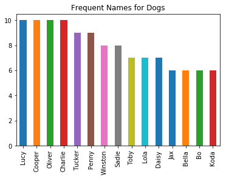

```python
name_list.plot(kind='bar', title = 'Frequent Names for Dogs');
```

```python
names_list = master.name.value_counts().index.tolist()
```

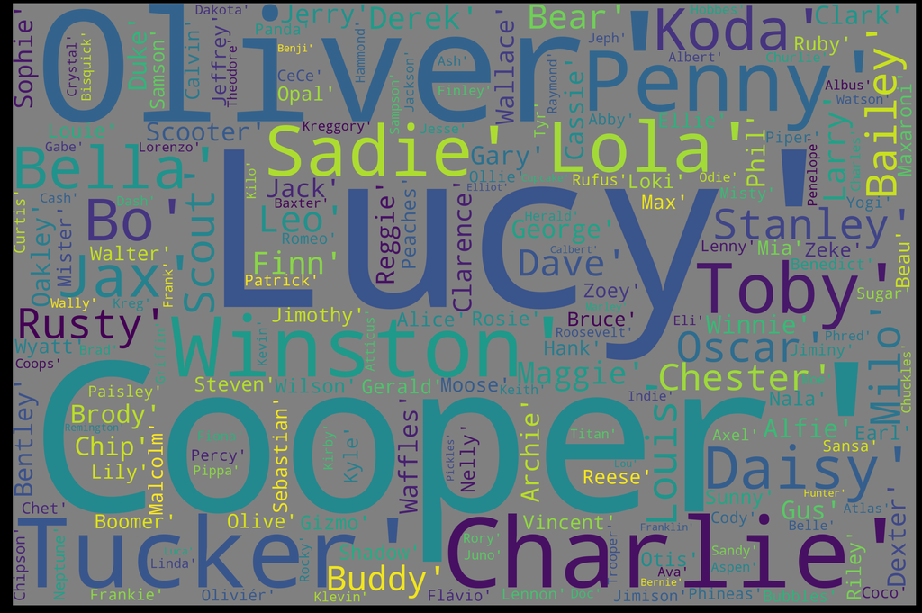

```python
from wordcloud import WordCloud, STOPWORDS
import matplotlib.pyplot as plt
text = names_list
wordcloud = WordCloud(
    width = 3000,
    height = 2000,
    background_color = 'gray',
    stopwords = STOPWORDS).generate(str(text))
fig = plt.figure(
    figsize = (40, 30),
    facecolor = 'k',
    edgecolor = 'k')
plt.imshow(wordcloud, interpolation = 'bilinear')
plt.axis('off')
plt.tight_layout(pad=0)
plt.show()
```

Resource:

- https://www.mikulskibartosz.name/word-cloud-from-a-pandas-data-frame/

## Most commonly predicted breeds

```python
breeds = prediction.p1.value_counts().head(10)
```

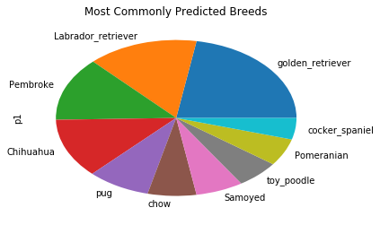

```python
breeds.plot(kind='pie', title = 'Most Commonly Predicted Breeds');
```

## Distribution of Dog Stages

```python
dog_stages_count = master['dog_stages'].value_counts()
```

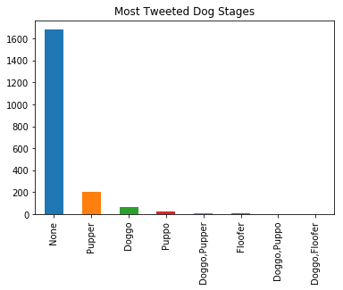

```python
x = np.arange(8)
dog_stages_count.plot(kind = 'bar', title = 'Most Tweeted Dog Stages')
plt.xticks(x, ('None', 'Pupper', 'Doggo', 'Puppo', 'Doggo,Pupper', 'Floofer', 'Doggo,Puppo', 'Doggo,Floofer'));
```

## Retweet Count versus Favorite Count

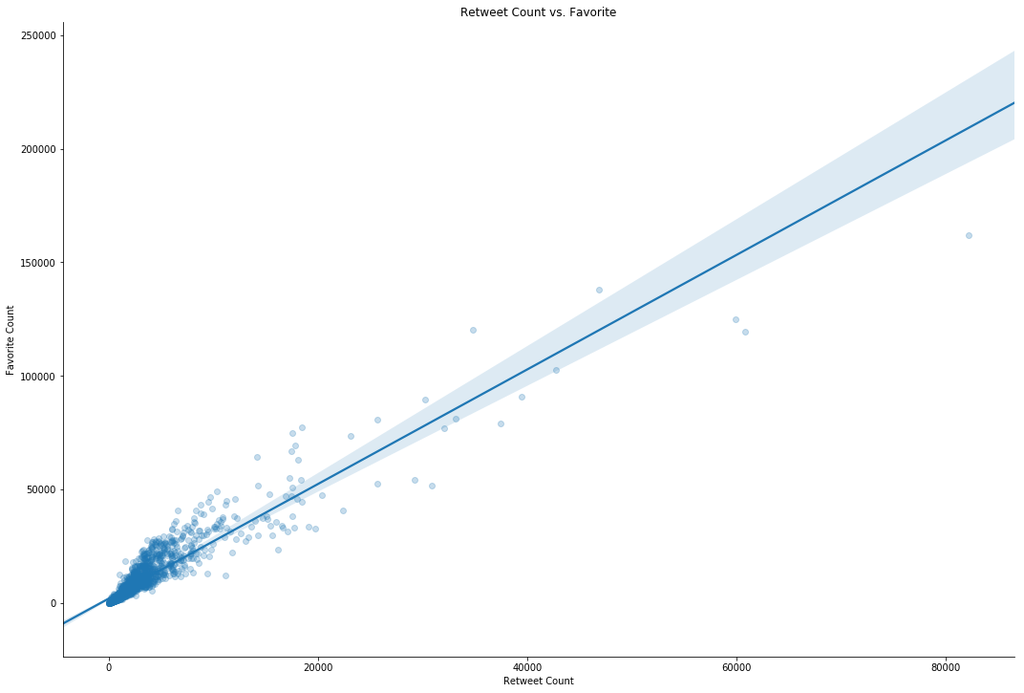

```python
sns.lmplot(x = 'retweets', y = 'favorites', data = master, size = 10, aspect = 1.5, scatter_kws={'alpha':1/4})
plt.title('Retweet Count vs. Favorite')
plt.xlabel('Retweet Count')
plt.ylabel('Favorite Count');
```

There is a positive correlation between favorites and retweeting.

Resources:

- https://seaborn.pydata.org/generated/seaborn.lmplot.html